# 1. Introduction

## 1.1 Problem Statement

Global warming or climate change is a problem that affects everybody, because our planet and our lives as we know them will be affected by it. The notion that humans are changing the surface of earth and with it its climate is not new, but so far our efforts to keep climate change at bay are not sufficient. There are many factors that can affect our ignorance about this problem, and they range from misinformation over convenience, political and religious beliefs, to simply not being a priority when other issues like paying our bills and putting food on the table are more urgent.

Often, climate change is denied or belittled even when there is an overwhelmig body of data. What doubters often do when they don't want to see connections, they say "Show me the smoking gun!". The goal of this project is to make some of the connections that are important for global warming obvious to lay persons. If people are more aware, there are actions everybody can take to make a difference that will probably not affect their standard of living.

### 1.1.1 Background

There is an overwhelming body of evidence demonstrating that the global average temperature has been increasing and that this anomaly is human-caused (anthropogenic). If unchecked, the results of global warming will be catastrophic, and signs are starting to become apparent. These include:

- Regression of glaciers in mountains and the arctic and antarctic regions
- Increased number and severity of storms including hurricanes and tornados
- Droughts, decrease of surface and ground water for agriculture leading to starvation and migration
- Increased number and severity of hot weather events leading to wild fires and death by heat stroke
- Extinction of species that have lost their habitat
- Release of methane and potentially pathogenic organisms from permafrost

Nevertheless, our species *Homo sapiens* seems to be unable or unwilling to take the appropriate measures to fight global warming. We have all the evidence needed and probably even the technology and tools to keep global warming at bay, if there were just a political and societal reckoning that we are in trouble and need to act.

### 1.1.2 Motivation

Why is this topic important to me and why should it be important to everybody? We should do our best to conserve our planet, not only for ourselves, but for future generations of humans and other organisms. In 1972, "The Limits to Growth" by Meadows, Meadows, Randers, & Behrens, published in 1972, the first report published by the "Club of Rome" (https://www.clubofrome.org/) used computer simulations to demonstrate that many factors, such as population, are growing at an exponential rate but also that that kind of growth cannot continue forever, because we will run out of resources and because there will be negative consequences of growth, such as, pollution (see Figure below; this figure is a beautified rendition of the original black-and-white version).

[figure not shown]

According to this figure, we are close to a point when resources become scarce and pollution will become so bad that the population will stop growing and eventually decrease. Unfortunately, a decrease in population is not expected to be a peaceful gradual transition, but it will involve conflict, mass migration, starvation and disease. If we want to avoid such an outcome, we need to proactively keep the causes of climate change as small as possible.

### 1.1.3 What are the causes and why don't we do enough about them?

I will explain what I think some of the causes of global warming are and why we don't do enough to keep them at bay.

- *Population:* The population has doubled in half a century. A lot of this has to do with advances in agriculture and medicine: antiseptics, vaccines, and antibiotics. Birth control medications were introduced in the 1960s dampening some of the growth caused by medical advances. However, it is not used everywhere due to availability, cultural, and religious values. Humans are heterotrophs, and more humans will require more resources to produce more food.
- *Fossil fuels:* Fossil fuels, such as coal, oil, and natural gas are fossilized organisms, mostly plants, that have accumulated and been buried underground for millions of years. These autotroph organisms have captured carbon dioxide from the atmosphere and incorporated carbon into hydrocarbons (mostly carbohydrates) through photosynthesis before being buried and fossilized. Humans have found ways to extract these fossil fuels and burn them (hydrocarbons back to carbon dioxide) for maybe two millenia, but en mass for about two centuries. Releasing that much carbon dioxide so quickly back into the atmorphere without recapturing the majority of it through photosynthesis has contributed to global warming through the greenhouse effect. Carbon dioxide acts like a greenhouse by reflecting some of the heat radiating from earth back to earth. Producing and selling fossil fuels is very lucrative and using them is very convenient, but the environmetal impact is usually not considered as a cost.
- *Standard of living:* Especially in developed countries, the standard of living has increased and resulted in bigger areas used for living more conveniently (which requires heating and cooling), using more goods, which are often imported, more travel and traffic. Most of these activities involve energy usage, until recently mostly powered through fossil fuels and only recently replaced in part by renewable energy.
- *Deforestation:* Another important factor is deforestation. Forests are often called the lungs of the planet, because they capture carbon dioxide through photosynthesis. With an increasing population and more need for human settlements and agricultural areas to provide food, the area of forests has shrunk a lot.

### 1.1.4 Proposed work

I will seek to demonstrate relationships between the factors mentioned above and global warming that would be convincing to a general audience. If we can all agree on the fact that we have a problem, we will be much more likely to address it successfully.

## 1.2 Summary of Conclusions

Data for global temperature, population, greenhouse gas emissions, and gross domestic products was obtained from trusted sources and initially explored using visualization of the individual data sets as well as correlation between data sets.

Where strong correlations were found, linear models were built and most of these models had adjusted R squareds of close to of above 0.9, incidating very clear correlations, the strongest ones between global temperature and population, global temperature and greenhouse gas emissions, and global temperature and both population and greenhouse gas emissions (including interaction terms). These correlations make it almost impossibly to ignore human contribution to global warming.

Stratification was used to analyze which categories of countries are mostly responsible for different measures affecting global warming and their trends.

Time series models based on historic data were successfully used to forecast the trend of the different measures investigated since 2010.

# 2. Data Sources and Preparation

## 2.0 Importing libraries needed

```python
# Importing libraries needed
import numpy as np
import numpy.random as nr
import pandas as pd
import statsmodels.formula.api as smf
import statsmodels.api as sm
from statsmodels.graphics.regressionplots import influence_plot, plot_regress_exog
from sklearn.preprocessing import normalize, StandardScaler
import scipy.stats as ss
import matplotlib.pyplot as plt
import seaborn as sns
import patsy
import warnings
# ARIMA libraries
import statsmodels.tsa.seasonal as sts
import statsmodels.tsa.arima_process as arima
from statsmodels.tsa.arima.model import ARIMA, ARIMAResults
from statsmodels.tsa.stattools import adfuller, kpss
from statsmodels.tsa.holtwinters import Holt, ExponentialSmoothing
from statsmodels.stats.diagnostic import acorr_ljungbox
import pmdarima as pm
import statsmodels.graphics.tsaplots as splt
from statsmodels.tsa.statespace.sarimax import SARIMAX
warnings.simplefilter(action='ignore', category=Warning)
%matplotlib inline
```

## 2.1 Temperature

Temperature was evaluated "in bulk" as annual global mean surface temperature. Since global warming is a global problem that depends on global factors (such as greenhouse gas emissions), it was not considered worthwhile to look at temperatures by region or continent, land or sea, or season. It is assumed that these differences cancel each other out globally and annually. This does not mean that such differences are not important; they just don't add any value to this study.

### 2.1.1 Temperature Data Source

"Global Mean Estimates based on Land Ocean Data" are available at NASA (https://data.giss.nasa.gov/gistemp/graphs/graph_data/Global_Mean_Estimates_based_on_Land_and_Ocean_Data/graph.txt). This data was used as the dependent or response variable. The following code loads the data set. It is available as a text file. It was loaded into Excel with the appropriate column separation, the header was removed, and the data was saved as a CSV file. The data is available as raw data (No_Smoothing) and with Lowess smoothing (Lowess(5)). It covers the years 1880 to 2022.

```python
# Load temperature data from
# https://data.giss.nasa.gov/gistemp/graphs/graph_data/Global_Mean_Estimates_based_on_Land_and_Ocean_Data/graph.txt
# original text file was converted to a csv file in excel
World_Temp = pd.read_csv('data/giss_nasa_temp.csv')
print('First three entries:')
print(World_Temp.head(3))
print('\nLast three entries')
print(World_Temp.tail(3))
```

```
First three entries:
   Year  No_Smoothing  Lowess(5)
0  1880         -0.17      -0.10
1  1881         -0.09      -0.13
2  1882         -0.11      -0.17

Last three entries
     Year  No_Smoothing  Lowess(5)
140  2020          1.01       0.91
141  2021          0.84       0.91
142  2022          0.89       0.90
```

To simplify column names, "No_smoothing" was replaced with "Temp" and "Lowess(5)" was replaced with "TempS".

```python
World_Temp.columns=['Year', 'Temp', 'TempS']
World_Temp.head(3)
```

|  | Year | Temp | TempS |
| --- | --- | --- | --- |
| 0 | 1880 | -0.17 | -0.10 |
| 1 | 1881 | -0.09 | -0.13 |
| 2 | 1882 | -0.11 | -0.17 |

### 2.1.2 Temperature Data Preparation for Linear Models

A function to select data from a specific time range to adjust the time frame to other data is defined.

```python
def select_range(df, start_year=1880, end_year=2022):
    df = df.loc[start_year<=df.loc[:, 'Year']][df.loc[:, 'Year']<=end_year]
    df.reset_index(drop=True, inplace=True)
    print('First three lines:')
    print(df.head(3))
    print('\nLast three lines:')
    print(df.tail(3))
    return(df)
```

Testing the function with 1980 and 2010 as start_year and end_year.

```python
World_Temp_1980_2010 = select_range(World_Temp, 1980, 2010)
```

```
First three lines:
   Year  Temp  TempS
0  1980  0.26   0.20
1  1981  0.32   0.21
2  1982  0.14   0.21

Last three lines:
    Year  Temp  TempS
28  2008  0.54   0.64
29  2009  0.65   0.64
30  2010  0.72   0.64
```

### 2.1.3 Temperature Data Preparation for Time Series Analysis

Time series analysis requires the data to be converted into a series with data as index column. Time series were created for Temp (raw data) and TempS (smoothed data).

```python
ts_Temp = pd.Series(World_Temp.Temp)
ts_Temp.index = pd.date_range(start = '1-1-1880', end = '12-31-2022', freq = 'Y')
ts_Temp.head(3)
```

```
1880-12-31   -0.17
1881-12-31   -0.09
1882-12-31   -0.11
Freq: A-DEC, Name: Temp, dtype: float64
```

```python
ts_TempS = pd.Series(World_Temp.TempS)
ts_TempS.index = pd.date_range(start = '1-1-1880', end = '12-31-2022', freq = 'Y')
ts_TempS.head(3)
```

```
1880-12-31   -0.10
1881-12-31   -0.13
1882-12-31   -0.17
Freq: A-DEC, Name: TempS, dtype: float64
```

## 2.2 Population

The most basic measure for something being caused by humans (anthropogenic) is the change of the response variable as a function of the mere existence of humans or human population. If there is a correlation between global temperature and human populations, we can answer the question **that** humans cause global warming. Subsequent questions will then address **how** humans cause global warming.

### 2.2.1 Population Data Source

Population data is available at https://ourworldindata.org/population-growth in a CSV file called "population.csv", which is loaded and examined with the code below.

```python
# Load world population data from https://ourworldindata.org/population-growth
pop_complete = pd.read_csv('data/population.csv')
print(pop_complete.shape)
print(pop_complete.keys())
```

```
(18288, 24)
Index(['Country name', 'Year', 'Population',
       'Population of children under the age of 1',
       'Population of children under the age of 5',
       'Population of children under the age of 15',
       'Population under the age of 25', 'Population aged 15 to 64 years',
       'Population older than 15 years', 'Population older than 18 years',
       'Population at age 1', 'Population aged 1 to 4 years',
       'Population aged 5 to 9 years', 'Population aged 10 to 14 years',
       'Population aged 15 to 19 years', 'Population aged 20 to 29 years',
       'Population aged 30 to 39 years', 'Population aged 40 to 49 years',
       'Population aged 50 to 59 years', 'Population aged 60 to 69 years',
       'Population aged 70 to 79 years', 'Population aged 80 to 89 years',
       'Population aged 90 to 99 years', 'Population older than 100 years'],
      dtype='object')
```

### 2.2.2 Population Data Preparation for Linear Models

This population data set is much more detailed than what we need. The population is broken up into age groups in columns. Plus, the range of years is given for different countries, but also "World" and categories of countries, such as "High-income countries". First, we will reduce the columns to the first three columns and rename Population to Pop.

```python
pop_total = pop_complete.loc[:, ('Country name', 'Year', 'Population')]
pop_total.rename(columns = {'Population':'Pop'}, inplace=True)
pop_total.head(3)
```

|  | Country name | Year | Pop |
| --- | --- | --- | --- |
| 0 | Afghanistan | 1950 | 7480464 |
| 1 | Afghanistan | 1951 | 7571542 |
| 2 | Afghanistan | 1952 | 7667534 |

Next, a function to select data from a specific country and a specific time range is defined.

```python
def select_country_range (df, Country_name, start_year=1950, end_year=2021):
    df = df.loc[df.loc[:, 'Country name']== Country_name]
    df = df.loc[start_year<=df.loc[:, 'Year']][df.loc[:, 'Year']<=end_year]
    df.reset_index(drop=True, inplace=True)
    print('First three lines:')
    print(df.head(3))
    print('\nLast three lines:')
    print(df.tail(3))
    return(df)
```

Testing the function with World as Country_name and 1980 and 2010 as start_year and end_year.

```python
World_Pop_1980_2010 = select_country_range(pop_total, 'World', 1980, 2010)
```

```
First three lines:
  Country name  Year         Pop
0        World  1980  4444008000
1        World  1981  4524627500
2        World  1982  4607984600

Last three lines:
   Country name  Year         Pop
28        World  2008  6811597300
29        World  2009  6898306000
30        World  2010  6985603000
```

### 2.2.3 Population Data Preparation for Time Series Analysis

```python
# Select World population of entire range
World_Pop = select_country_range(pop_total, 'World')

ts_Pop = pd.Series(World_Pop.Pop)
ts_Pop.index = pd.date_range(start = '1-1-1950', end = '12-31-2021', freq = 'Y')
ts_Pop.head(3)
```

```
First three lines:
  Country name  Year         Pop
0        World  1950  2499322000
1        World  1951  2543130400
2        World  1952  2590271000

Last three lines:
   Country name  Year         Pop
69        World  2019  7764951000
70        World  2020  7840953000
71        World  2021  7909295000
```

```
1950-12-31    2499322000
1951-12-31    2543130400
1952-12-31    2590271000
Freq: A-DEC, Name: Pop, dtype: int64
```

## 2.3 Greenhouse Gas Emissions

As shown in sections 3 and 4 below, there is a clear correlation between population and global warming. We will now trace back the human-caused factors that do cause global warming. There are several greenhouse gases and they differ in the amount released and their potency as greenhouse gases. Therefore, they are often presented as carbon dioxide equivalents according to the Center for Climate and Energy Solutions (https://www.c2es.org/content/international-emissions/#:~:text=CO2%20accounts%20for%20about%2076,6%20percent%20to%20global%20emissions) or the United States Environmental Protection Agency (https://www.epa.gov/ghgemissions/overview-greenhouse-gases). According to these sources, CO2 emissions account for 76-79% and methane for 16-12% of the greenhouse gas emissions, combined for more than 90%. For this project, we will therefore ignore the remainig <10%, which are caused by nitrous oxide (N2O) and various fluorinated and chlorinated organic compounds. The amount of those compounds over time is assumed to be <10% of and approximately proportional to CO2 and methane emissions.

### 2.3.1 Greenhouse Gas Emissions Data Sources

Datasets for the annual emissions of both CO2 and methane by country can be found at https://outworldindate.org: A CSV file called "annual-co2-emissions-per-country.csv" is found at https://ourworldindata.org/co2-and-greenhouse-gas-emissions A CSV file called "methane-emissions.csv" is found at https://ourworldindata.org/grapher/methane-emissions. Both files were loaded and 'World' was selected as Country name.

The three biggest sources of CO2 are (in that order) (https://ourworldindata.org/emissions-by-sector)

- energy production and heating,
- transportation, and
- manufacturing and construction

The three biggest sources of methane are (in that order) (https://ourworldindata.org/emissions-by-sector)

- agriculture,
- fugitive emissions (leaks from fossil fuel production, methane storage and transportation, and appliances), and
- fermentation of waste

### 2.3.2. Greenhouse Gas Emissions Data Preparation

#### 2.3.2.1.1 CO2 Emissions Data Preparation for Linear Models

```python
# Loading the CO2 dataset
CO2_complete = pd.read_csv('data/annual-co2-emissions-per-country.csv')
CO2_complete.head(3)
```

|  | Entity | Code | Year | Annual CO₂ emissions |
| --- | --- | --- | --- | --- |
| 0 | Afghanistan | AFG | 1949 | 14656.0 |
| 1 | Afghanistan | AFG | 1950 | 84272.0 |
| 2 | Afghanistan | AFG | 1951 | 91600.0 |

```python
# Changing 'Entity' to 'Country name' and 'Annual CO2 emissions' to 'CO2'
CO2_complete.columns=['Country name', 'Code', 'Year', 'CO2']
CO2_complete.head(3)
```

|  | Country name | Code | Year | CO2 |
| --- | --- | --- | --- | --- |
| 0 | Afghanistan | AFG | 1949 | 14656.0 |
| 1 | Afghanistan | AFG | 1950 | 84272.0 |
| 2 | Afghanistan | AFG | 1951 | 91600.0 |

```python
# Creating dataframe with only World and the entire data range
World_CO2 = select_country_range(CO2_complete, 'World', 1750, 2022)
```

```
First three lines:
  Country name      Code  Year        CO2
0        World  OWID_WRL  1750  9305937.0
1        World  OWID_WRL  1751  9407229.0
2        World  OWID_WRL  1752  9505168.0

Last three lines:
    Country name      Code  Year           CO2
270        World  OWID_WRL  2020  3.500774e+10
271        World  OWID_WRL  2021  3.681654e+10
272        World  OWID_WRL  2022  3.714979e+10
```

#### 2.3.2.1.2 CO2 Emissions Data Preparation for Time Series Analysis

```python
ts_CO2 = pd.Series(World_CO2.CO2)
ts_CO2.index = pd.date_range(start = '1-1-1750', end = '12-31-2022', freq = 'Y')
ts_CO2.head(3)
```

```
1750-12-31    9305937.0
1751-12-31    9407229.0
1752-12-31    9505168.0
Freq: A-DEC, Name: CO2, dtype: float64
```

#### 2.3.2.2.1 Methane Emissions Data Preparation for Linear Models

```python
# Loading the methane dataset
Methane_complete = pd.read_csv('data/methane-emissions.csv')
Methane_complete.head(3)
```

|  | Entity | Code | Year | Annual methane emissions in CO₂ equivalents |
| --- | --- | --- | --- | --- |
| 0 | Afghanistan | AFG | 1850 | 3594926.5 |
| 1 | Afghanistan | AFG | 1851 | 3615134.5 |
| 2 | Afghanistan | AFG | 1852 | 3635346.8 |

```python
# Changing 'Entity' to 'Country name' and 'Annual methane emissions in CO2 equivalents' to 'Methane'
Methane_complete.columns=['Country name', 'Code', 'Year', 'Methane']
Methane_complete.head(3)
```

|  | Country name | Code | Year | Methane |
| --- | --- | --- | --- | --- |
| 0 | Afghanistan | AFG | 1850 | 3594926.5 |
| 1 | Afghanistan | AFG | 1851 | 3615134.5 |
| 2 | Afghanistan | AFG | 1852 | 3635346.8 |

```python
# Creating dataframe with only World and the entire data range
World_methane = select_country_range(Methane_complete, 'World', 1850, 2021)
```

```
First three lines:
  Country name      Code  Year       Methane
0        World  OWID_WRL  1850  1.239387e+09
1        World  OWID_WRL  1851  1.244030e+09
2        World  OWID_WRL  1852  1.250667e+09

Last three lines:
    Country name      Code  Year       Methane
169        World  OWID_WRL  2019  1.032124e+10
170        World  OWID_WRL  2020  1.037299e+10
171        World  OWID_WRL  2021  1.050691e+10
```

#### 2.3.2.2.2 Methane Emissions Data Preparation for Time Series Analysis

```python
ts_Methane = pd.Series(World_methane.Methane)
ts_Methane.index = pd.date_range(start = '1-1-1850', end = '12-31-2021', freq = 'Y')
ts_Methane.head(3)
```

```
1850-12-31    1.239387e+09
1851-12-31    1.244030e+09
1852-12-31    1.250667e+09
Freq: A-DEC, Name: Methane, dtype: float64
```

## 2.4 Gross Domestic Product (GDP)

"The gross domestic product is a monetary measure of the market value of all the final goods and services produced in a specific time period by a country or countries." (https://en.wikipedia.org/wiki/Gross_domestic_product) This measure is often used as an indicator of the economic health of countries. It could also be argued that economic activity typically involves burning of fossil fuels and greenhouse gas emissions.

### 2.4.1 GDP Data Source

A dataset of GDP of different countries from 1960 to 2022 is availabe at the World Bank (https://data.worldbank.org/indicator/NY.GDP.MKTP.CD) as a CSV file named "API_NY.GDP.MKTP.CD_DS2_en_csv_v2_6224532.csv".

### 2.4.2 GDP Data Preparation

This file was analyzed. It is written with countries in rows and years in columns. I copied the year and World rows, copied and transformed them into a new CSV file for easier handling and then imported it.

```python
World_GDP = pd.read_csv('data/WorldBankGDP/WorldGDP.csv')
World_GDP.head(3)
```

|  | Year | GDP |
| --- | --- | --- |
| 0 | 1960 | 1.384860e+12 |
| 1 | 1961 | 1.449220e+12 |
| 2 | 1962 | 1.550820e+12 |

# 3. Exploratory Data Analysis

## 3.1. Visualization and Analysis of Data Used

### 3.1.1 Temperature

Annual temperatures are available from 1880 to 2022 as actual estimates (No_Smoothing) and with smoothing (Lowess(5)), where local regressions are made over 5-year intervals. Both columns are kept for now. The values are given as a difference from the average temperate in the years 1951-1980.

The code below plots the actual and smoothed temperature over the available time range.

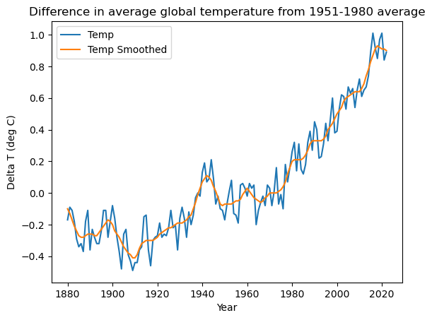

```python
# Plot temperature versus year
sns.lineplot(data=World_Temp, x='Year', y='Temp', label='Temp')
sns.lineplot(data=World_Temp, x='Year', y='TempS', label='Temp Smoothed')
plt.xlabel('Year')
plt.ylabel('Delta T (deg C)')
plt.title('Difference in average global temperature from 1951-1980 average')
plt.show()
```

#### Testing temperature for autocorrelation and partial autocorrelation

The following is a function borrowed from Notebook 32.

```python
def auto_partial_corr_plot(ts, lags=40):
    _,ax = plt.subplots(2,1, figsize=(8,8))
    _=splt.plot_acf(ts, lags = lags, ax=ax[0]);
    _=splt.plot_pacf(ts, lags = lags, method='yw', ax=ax[1]);
```

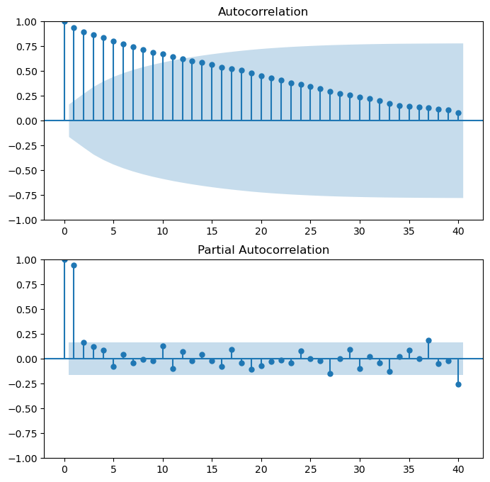

```python
auto_partial_corr_plot(ts_Temp)
```

**Figure 3.1.1.2** For the Temp data set, there is clear autocorrelation for several lags and partial autocorrelation for 2 lags, which is expected for a time series.

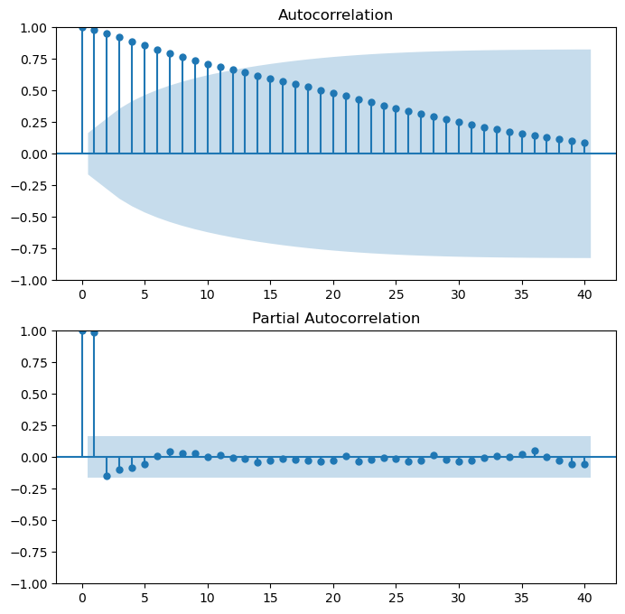

```python
auto_partial_corr_plot(ts_TempS)
```

**Figure 3.1.1.3** For the TempS data set, there is clear autocorrelation for several lags and partial autocorrelation for 2 lags, which is expected for a time series. The values of the partial autocorrelation are smaller after the first few lags, which is probably due to the smoothing.

#### Testing temperature for stationarity

The following function is borrowed from Notebook 32.

```python
def test_stationarity(series, regression_model='c', rounding=3):
    """Function to test the stationarity of time series using:
    1. Augmented Dicky Fuller test using AIC
    2. KPSS test for constant

    Arguments:
        Series: the time series to be evaluated.
        regression_model: model to be used:
            'c' - model with a constant
            'ct' - model with a constant and trend
        rounding: the number of digits to display in printed output.
    """
    if regression_model not in ['c','ct']:
        print('Error!: argument regression model must be one of {\'c\',\'ct\'}')
        return
    with warnings.catch_warnings():
        warnings.filterwarnings("ignore")
        kpss_test = kpss(series, regression=regression_model)
        ADF_test = adfuller(series, regression=regression_model, autolag="AIC")
    return [round(ADF_test[0],rounding), round(ADF_test[4]['5%'],rounding), round(ADF_test[1],rounding),
                                       round(kpss_test[0],rounding), round(kpss_test[1],rounding)]

def stationary_tests(series, names, regression_model='c', rounding=3):
    test_columns = ['ADF_statistic','ADF_conf_int','ADF_p_value','KPSS_statistic','KPSS_p_value']
    out = pd.DataFrame(index=names, columns=test_columns)
    for ser, name in zip(series,names):
        out.loc[name,:] = test_stationarity(ser, regression_model=regression_model, rounding=rounding)
    return out
```

```python
time_series = [ts_Temp,ts_TempS]
names = ['ts_Temp','ts_TempS']

for model in ['c','ct']:
    print('\nFor model ' + model)
    print(stationary_tests(time_series, names, regression_model=model))
```

```
For model c
         ADF_statistic ADF_conf_int ADF_p_value KPSS_statistic KPSS_p_value
ts_Temp          1.001       -2.883       0.994          1.433         0.01
ts_TempS         1.178       -2.884       0.996           1.44         0.01

For model ct
         ADF_statistic ADF_conf_int ADF_p_value KPSS_statistic KPSS_p_value
ts_Temp         -1.436       -3.443        0.85          0.343         0.01
ts_TempS        -1.031       -3.445        0.94          0.322         0.01
```

For both Temp and TempS time series, we cannot reject the null hypothesis of non-stationarity according to the small ADF statistic and large ADF p-value and we can reject the null hypothesis of stationarity according to the large KPSS statistic and small KPSS p-value. So, both series are non-stationary.

#### STL decomposition of Temp and TempS series

The function below is borrowed from Notebook 32.

```python
def decomp_ts(ts, freq = 'Y', model = 'additive'):
    res = sts.seasonal_decompose(ts, model = model)
    res.plot()
    return(pd.DataFrame({'resid': res.resid,
                         'trend': res.trend,
                         'seasonal': res.seasonal},
                       index = ts.index) )
```

```
            resid  trend  seasonal
1880-12-31    0.0  -0.17       0.0
```

|  | resid | trend | seasonal |
| --- | --- | --- | --- |
| 2022-12-31 | 0.0 | 0.89 | 0.0 |

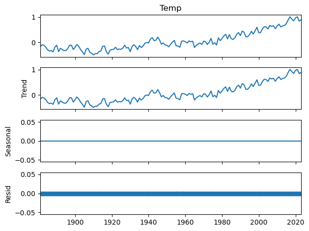

```python
decomp = decomp_ts(ts_Temp)
print(decomp[:1])
decomp[-1:]
```

**Figure 3.1.1.4**

```
            resid  trend  seasonal
1880-12-31    0.0   -0.1       0.0
```

|  | resid | trend | seasonal |
| --- | --- | --- | --- |
| 2022-12-31 | 0.0 | 0.9 | 0.0 |

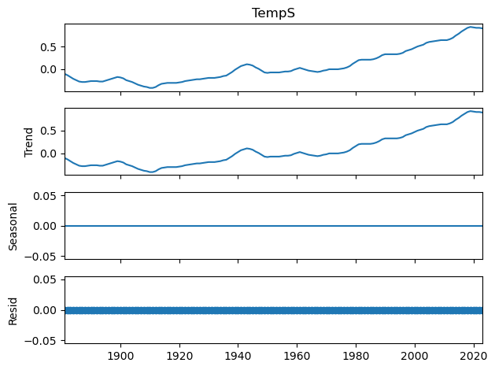

```python
decomp = decomp_ts(ts_TempS)
print(decomp[:1])
decomp[-1:]
```

**Figure 3.1.1.5**

Not surprisingly, there is no seasonality, because values were recorded annually. There is a trend, and once the trend is substracted, the data is basically a straight line with very small residuals. The trend with the Temp data has a lot of noise; the trend with the smoothed Temp data (TempS) looks quite smoth.

### 3.1.2 Population

This data is only available from 1950 to 2021. Other datasets exist, where the population is extrapolated to earlier times, but these estimates will be ignored here.

The code below selects the World populations from pop_total and plots the world population from 1950 to 2021.

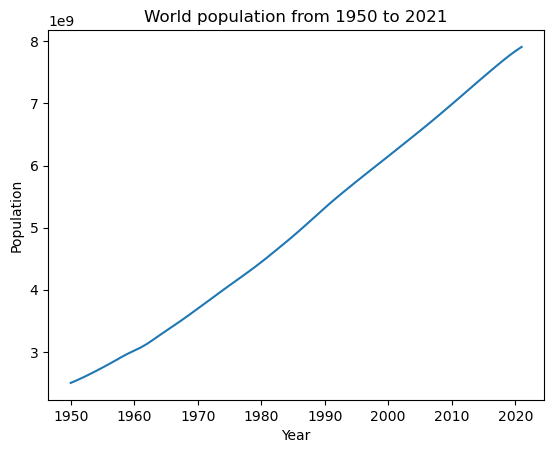

```python
# Plot population versus year
plt.plot('Year', 'Pop', data=World_Pop)
plt.xlabel('Year')
plt.ylabel('Population')
plt.title('World population from 1950 to 2021')
plt.show()
```

**Figure 3.1.2.1** Since about 1980, the increase in world population seems linear. Before that it looked more exponential.

#### Testing population for autocorrelation and partial autocorrelation

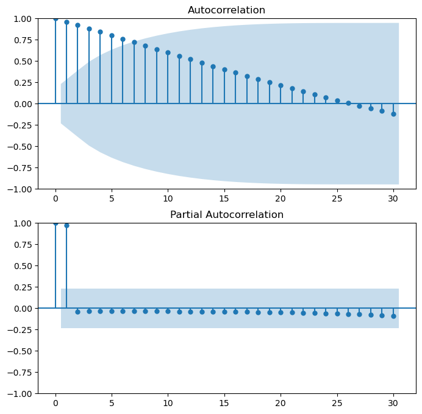

```python
auto_partial_corr_plot(ts_Pop, lags=30)
```

**Figure 3.1.2.2** There is clear autocorrelation for several lags and partial autocorrelation for 2 lags, which is expected for a time series.

#### Testing population for stationarity

```python
time_series = [ts_Pop]
names = ['ts_Pop']

for model in ['c','ct']:
    print('\nFor model ' + model)
    print(stationary_tests(time_series, names, regression_model=model))
```

```
For model c
       ADF_statistic ADF_conf_int ADF_p_value KPSS_statistic KPSS_p_value
ts_Pop         -2.09       -2.912       0.248          1.303         0.01

For model ct
       ADF_statistic ADF_conf_int ADF_p_value KPSS_statistic KPSS_p_value
ts_Pop         -1.59       -3.485       0.796          0.292         0.01
```

Due the small ADF statistic and large ADF p-value and large KPSS statistic and small KPSS p-value, we have to conclude non-stationarity.

#### STL decomposition of population series

```
            resid         trend  seasonal
1950-12-31    0.0  2.499322e+09       0.0
```

|  | resid | trend | seasonal |
| --- | --- | --- | --- |
| 2021-12-31 | 0.0 | 7.909295e+09 | 0.0 |

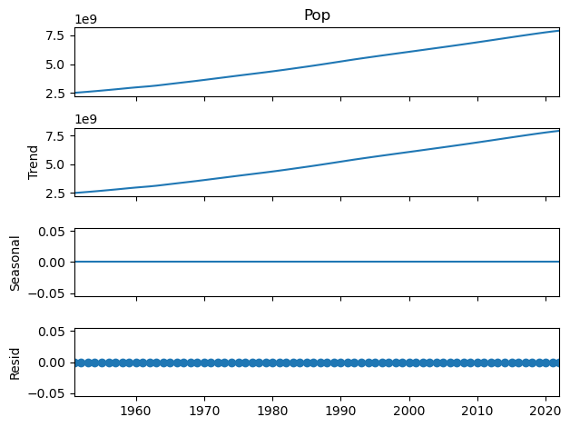

```python
decomp = decomp_ts(ts_Pop)
print(decomp[:1])
decomp[-1:]
```

Again, there is no seasonality and the data is dominated by the trend. Once the trend is taken out, the data is a straight line with small residuals.

### 3.1.3 Greenhouse Gas Emissions

#### 3.1.3.1 World-wide Carbon Dioxide Emissions

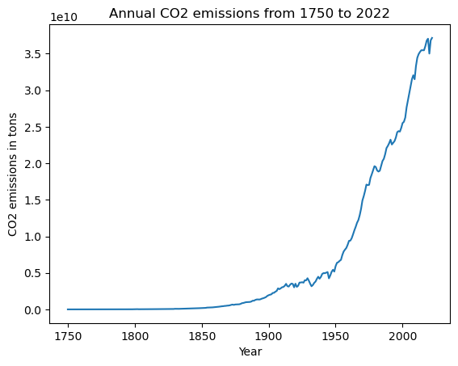

```python
# Plot CO2 versus year
plt.plot('Year', 'CO2', data=World_CO2)
plt.xlabel('Year')
plt.ylabel('CO2 emissions in tons')
plt.title('Annual CO2 emissions from 1750 to 2022')
plt.show()
```

**Figure 3.1.3.1.1** Since 1750 world-wide CO2 emissions have increased exponentially up to about 1970. Since then, the increase has been steady but rather linear.

#### Testing CO2 for autocorrelation and partial autocorrelation

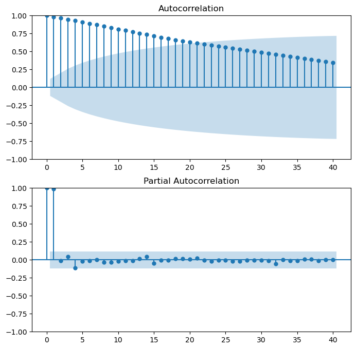

```python
auto_partial_corr_plot(ts_CO2)
```

**Figure 3.1.3.1.2** There is clear autocorrelation for several lags and partial autocorrelation for 2 lags, which is expected for a time series.

#### Testing CO2 for stationarity

```python
time_series = [ts_CO2]
names = ['ts_CO2']

for model in ['c','ct']:
    print('\nFor model ' + model)
    print(stationary_tests(time_series, names, regression_model=model))
```

```
For model c
       ADF_statistic ADF_conf_int ADF_p_value KPSS_statistic KPSS_p_value
ts_CO2         2.299       -2.873       0.999          1.796         0.01

For model ct
       ADF_statistic ADF_conf_int ADF_p_value KPSS_statistic KPSS_p_value
ts_CO2         1.317       -3.428         1.0          0.556         0.01
```

Due to the large ADF p-value and small KPSS p-value we have to assume non-stationarity.

#### STL decomposition of CO2 series

```
            resid      trend  seasonal
1750-12-31    0.0  9305937.0       0.0
```

|  | resid | trend | seasonal |
| --- | --- | --- | --- |
| 2022-12-31 | 0.0 | 3.714979e+10 | 0.0 |

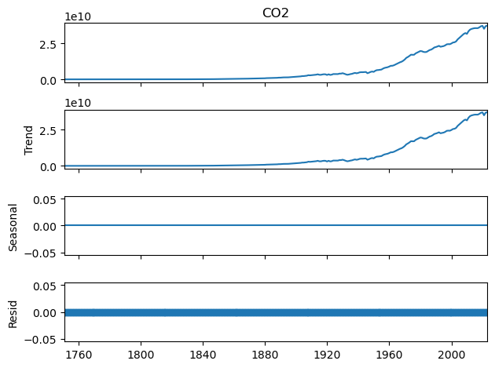

```python
decomp = decomp_ts(ts_CO2)
print(decomp[:1])
decomp[-1:]
```

**Figure 3.1.3.1.3** Again, there is no seasonality and the data is dominated by the trend. Once the trend is taken out, the data is a straight line with small residuals.

#### 3.1.3.2 World-wide Methane Emissions

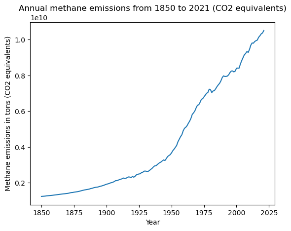

```python
# Plot Methane versus year
plt.plot('Year', 'Methane', data=World_methane)
plt.xlabel('Year')
plt.ylabel('Methane emissions in tons (CO2 equivalents)')
plt.title('Annual methane emissions from 1850 to 2021 (CO2 equivalents)')
plt.show()
```

**Figure 3.1.3.2.1** The dataset for methane starts a hundred years later thant he CO2 dataset. So, they are a little hard to compare. However, it is clear that today, the impact of methane is about a third of that of CO2.

#### Testing methane for autocorrelation and partial autocorrelation

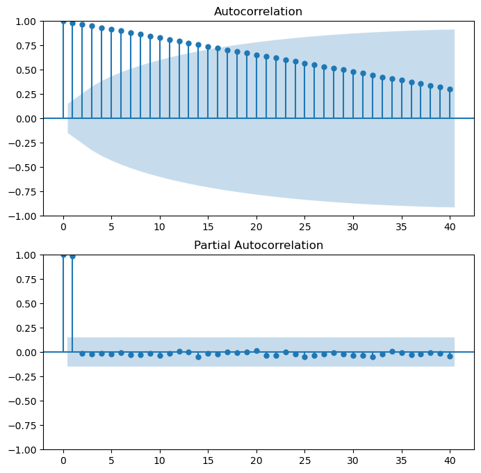

```python
auto_partial_corr_plot(ts_Methane)
```

**Figure 3.1.3.2.2** There is clear autocorrelation for several lags and partial autocorrelation for 2 lags, which is expected for a time series.

#### Testing methane for stationarity

```python
time_series = [ts_Methane]
names = ['ts_Methane']

for model in ['c','ct']:
    print('\nFor model ' + model)
    print(stationary_tests(time_series, names, regression_model=model))
```

```
For model c
           ADF_statistic ADF_conf_int ADF_p_value KPSS_statistic KPSS_p_value
ts_Methane         1.047        -2.88       0.995          1.692         0.01

For model ct
           ADF_statistic ADF_conf_int ADF_p_value KPSS_statistic KPSS_p_value
ts_Methane        -1.488       -3.438       0.833          0.446         0.01
```

Due to the large ADF p-value and small KPSS p-value we have to assume non-stationarity.

#### STL decomposition of methane series

```
            resid         trend  seasonal
1850-12-31    0.0  1.239387e+09       0.0
```

|  | resid | trend | seasonal |
| --- | --- | --- | --- |
| 2021-12-31 | 0.0 | 1.050691e+10 | 0.0 |

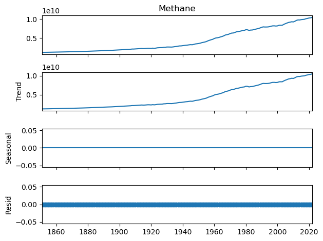

```python
decomp = decomp_ts(ts_Methane)
print(decomp[:1])
decomp[-1:]
```

**Figure 3.1.3.2.3** Again, there is no seasonality and the data is dominated by the trend. Once the trend is taken out, the data is a straight line with small residuals.

In summary, all our data series basically consist exclusively of trends.

#### 3.1.3.3 World-wide CO2 and Methane Emissions

CO2 and methane and their sum were plotted together to see which one would possibly be the best indicator for global warming. First, both data sets were adjusted to the same time frame (1850-2021). Then the data were merged into one data frame and a column for the sum of both CO2 and methane was added. The three series were plotted in one plot.

```python
# Preparing CO2 dataset to match Methane dataset
World_CO2_1850_2021 = select_range(World_CO2, start_year=1850, end_year=2021)
```

```
First three lines:
  Country name      Code  Year          CO2
0        World  OWID_WRL  1850  196751970.0
1        World  OWID_WRL  1851  198668110.0
2        World  OWID_WRL  1852  207414200.0

Last three lines:
    Country name      Code  Year           CO2
169        World  OWID_WRL  2019  3.704010e+10
170        World  OWID_WRL  2020  3.500774e+10
171        World  OWID_WRL  2021  3.681654e+10
```

```python
# Rename Methane dataset to match CO2 dataset name
World_methane_1850_2021 = World_methane
print(World_methane.head(3))
print()
print(World_methane.tail(3))
```

```
  Country name      Code  Year       Methane
0        World  OWID_WRL  1850  1.239387e+09
1        World  OWID_WRL  1851  1.244030e+09
2        World  OWID_WRL  1852  1.250667e+09

    Country name      Code  Year       Methane
169        World  OWID_WRL  2019  1.032124e+10
170        World  OWID_WRL  2020  1.037299e+10
171        World  OWID_WRL  2021  1.050691e+10
```

Defining a function for combining data frames.

```python
def combine_data(Combined_df, added_column_name, source_df, source_df_column_name):
    Combined_df = Combined_df
    Combined_df[added_column_name] = source_df.loc[:, source_df_column_name]
    return(Combined_df)
```

```python
# Combine CO2 and Methane data into World_GGE data frame (for greenhouse gas emissions)
World_GGE = combine_data(World_CO2_1850_2021, 'Methane', World_methane_1850_2021, 'Methane')
print(World_GGE.head(3))
print(World_GGE.tail(3))
```

```
  Country name      Code  Year          CO2       Methane
0        World  OWID_WRL  1850  196751970.0  1.239387e+09
1        World  OWID_WRL  1851  198668110.0  1.244030e+09
2        World  OWID_WRL  1852  207414200.0  1.250667e+09
    Country name      Code  Year           CO2       Methane
169        World  OWID_WRL  2019  3.704010e+10  1.032124e+10
170        World  OWID_WRL  2020  3.500774e+10  1.037299e+10
171        World  OWID_WRL  2021  3.681654e+10  1.050691e+10
```

Adding column GGE to the data frame. GGE is the sum of CO2 and methane emissions (in CO2 equivalents) that, as discussed above, account for more than 90% of greenhouse gas emissions. This is considered an appropriate approximation for total greenhouse gas emissions.

```python
# Add GGE to World_greenhouse_gas
World_GGE['GGE'] = World_GGE.CO2 + World_GGE.Methane
World_GGE.head(3)
```

|  | Country name | Code | Year | CO2 | Methane | GGE |
| --- | --- | --- | --- | --- | --- | --- |
| 0 | World | OWID_WRL | 1850 | 196751970.0 | 1.239387e+09 | 1.436139e+09 |
| 1 | World | OWID_WRL | 1851 | 198668110.0 | 1.244030e+09 | 1.442698e+09 |
| 2 | World | OWID_WRL | 1852 | 207414200.0 | 1.250667e+09 | 1.458081e+09 |

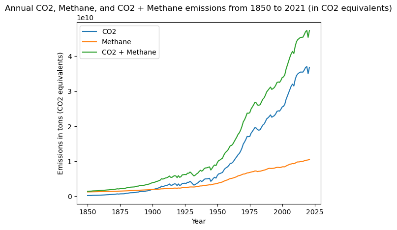

```python
# Plot CO2, Methane, and GGE versus year
sns.lineplot(data=World_GGE, x='Year', y='CO2', label='CO2')
sns.lineplot(data=World_GGE, x='Year', y='Methane', label='Methane')
sns.lineplot(data=World_GGE, x='Year', y='GGE', label='CO2 + Methane')
plt.xlabel('Year')
plt.ylabel('Emissions in tons (CO2 equivalents)')
plt.title('Annual CO2, Methane, and CO2 + Methane emissions from 1850 to 2021 (in CO2 equivalents)')
plt.show()
```

**Figure 3.1.3.3** It is interesting to see that up to about 1900 the effect of methane was bigger than that of CO2. Its origin was probably mostly from agriculture. After that, CO2 emissions increased more rapidly than methane emissions, especially after 1950. This was probably due to increased production and burning of fossil fuels for energy production and transportation (combustion engines in cars, diesel engines in trains and ships, and kerosine in planes), and manufacturing (e.g., steel production) and construction (e.g., concrete). For the purpose of this study, we will use the combined CO2 + Methane emissions or greenhouse gas emissions (GGE) going forward for linear models. For time series and forecasts, we will work with CO2 and Methane individually, because their trends are different.

### 3.1.4 Gross Domestic Product (GDP)

Initially, the entire dataset of World GDP was visualized.

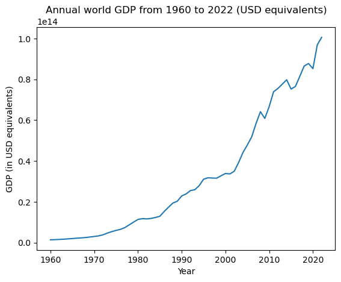

```python
plt.plot('Year', 'GDP', data=World_GDP)
plt.xlabel('Year')
plt.ylabel('GDP (in USD equivalents)')
plt.title('Annual world GDP from 1960 to 2022 (USD equivalents)')
plt.show()
```

**Figure 3.1.4** The increase in GDP looks exponential and even more so than population. So, it seems like GDP per capita has also increased.

### 3.1.X Other Data Considered but not Used

In the proposal, I also wanted to include standard of living and deforrestation as variables.

It turned out that standard of living or human development index (HDI) are compiled from various other measures, such as health, education, income, and living conditoins. These measures were found to be too complex for this study. At least in theory, gross domestic product (GDP) is a measure that is to some degree related to standard of living.

For deforestation, there is just not enough good data over time. I found some datasets that had data in five- or ten-year increments over only 2-3 decades. For this study, that is just not a long enough time frame. Since a lot of deforestation occurs through burning of trees and brushes, the greenhouse gases emitted in this process should be included in greenhouse gas emissions and should therefore be accounted for. Deforestation also decreases carbon capture, which is probasly not specifically accounted for.

Another factor that is not specifically accounted for is carbon capture or release by or from oceans. This depends on carbon dioxide levels in the atmosphere, the oceans' temperature and chemistry (for instance acidity).

While all these factors are important, either there was no good data available or they are too complex to be included in this study.

## 3.2 Combining Data Sets

### 3.2.1 Temperature and Population

Since we only have population data from 1950 to 2021, we will also drop the temperature data before 1950 and for 2022 and then merge the data into a combined data frame called Combined_df. I will add other variables to this data frame later on.

```python
World_Temp_1950_2021 = select_range(World_Temp, 1950, 2021)
```

```
First three lines:
   Year  Temp  TempS
0  1950 -0.17  -0.07
1  1951 -0.07  -0.07
2  1952  0.01  -0.07

Last three lines:
    Year  Temp  TempS
69  2019  0.97   0.92
70  2020  1.01   0.91
71  2021  0.84   0.91
```

Confirming that both data frames have the same length.

```python
print(len(World_Pop), len(World_Temp_1950_2021))
```

```
72 72
```

```python
# Combining population and temperature data into one data frame
Combined_df = combine_data(World_Temp_1950_2021, 'Pop', World_Pop, 'Pop')
Combined_df.head(3)
```

|  | Year | Temp | TempS | Pop |
| --- | --- | --- | --- | --- |
| 0 | 1950 | -0.17 | -0.07 | 2499322000 |
| 1 | 1951 | -0.07 | -0.07 | 2543130400 |
| 2 | 1952 | 0.01 | -0.07 | 2590271000 |

Now that we have both data sets conveniently in one dataframe. We can plot them to see if we see any relationship. A function is defined for plotting Temp and TempS versus predictor variable(s).

```python
def plot_y1_and_y2_versus_x1_and_x2(df, x1, x2, y1='Temp', y2='TempS', ylabel='Delta T (deg C)'):
    fig, ax = plt.subplots(1, 2, figsize=(9,4))
    sns.scatterplot(data=df, x=x1, y=y1, ax=ax[0])
    ax[0].set_xlabel(x1)
    ax[0].set_ylabel(ylabel)
    ax[0].set_title(y1 + ' vs. ' + x1)
    sns.scatterplot(data=df, x=x2, y=y2, ax=ax[1])
    ax[1].set_xlabel(x2)
    ax[1].set_ylabel(ylabel)
    ax[1].set_title(y2 + ' vs. ' + x1)
    plt.show()
```

Use the function to plot World population versus Temp and TempS.

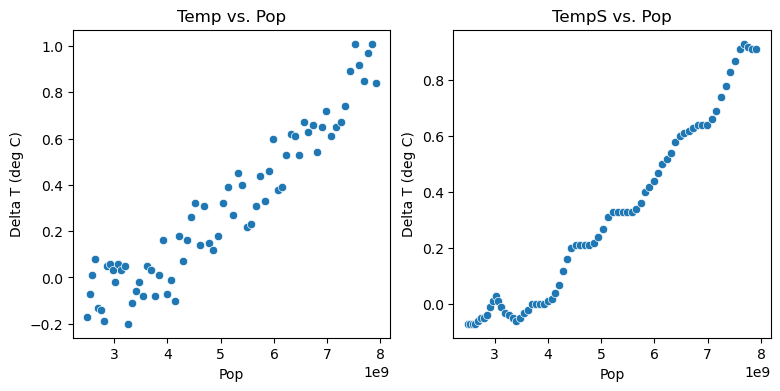

```python
plot_y1_and_y2_versus_x1_and_x2(Combined_df, 'Pop', 'Pop')
```

**Figure 3.2.1** There is a strong correlation between population and change in temperature. A linear model might be able to explain the correlation, but perhaps a better fit could be obtained with a logarithmic transformation or a polynomial linear model.

### 3.2.2 Temperature and Greenhouse Gas Emissions

Greenhouse gas emissions are a major contributor to global warming, although some persons (e.g., our former President and some current presidential candidates, our current speaker of the house, the previous president of Brasil, and the new president of Argentina) deny that relationship. Initially, the correlation is explored using as much data as possible, i.e., from 1880 to 2021, where we have data for greenhouse gas emissions and temperature. As explained above, the combined CO2 and methane emissions will be used and labeled GGE as an approximateion for greenhouse emissions.

```python
# Adjusting World_GGE to the relevant range
World_GGE_1880_2021 = select_range(World_GGE, start_year=1880, end_year=2021)
```

```
First three lines:
  Country name      Code  Year          CO2       Methane           GGE
0        World  OWID_WRL  1880  853916350.0  1.544128e+09  2.398045e+09
1        World  OWID_WRL  1881  883544060.0  1.561731e+09  2.445275e+09
2        World  OWID_WRL  1882  933360100.0  1.579700e+09  2.513060e+09

Last three lines:
    Country name      Code  Year           CO2       Methane           GGE
139        World  OWID_WRL  2019  3.704010e+10  1.032124e+10  4.736135e+10
140        World  OWID_WRL  2020  3.500774e+10  1.037299e+10  4.538072e+10
141        World  OWID_WRL  2021  3.681654e+10  1.050691e+10  4.732346e+10
```

```python
# Adjusting World_Temp to the relevant range
World_Temp_1880_2021 = select_range(World_Temp, 1880, 2021)
```

```
First three lines:
   Year  Temp  TempS
0  1880 -0.17  -0.10
1  1881 -0.09  -0.13
2  1882 -0.11  -0.17

Last three lines:
     Year  Temp  TempS
139  2019  0.97   0.92
140  2020  1.01   0.91
141  2021  0.84   0.91
```

```python
# Combining greenhouse gas emissions and temperature data into one data frame
Combined_df2 = combine_data(World_Temp_1880_2021, 'GGE', World_GGE, 'GGE')
Combined_df2.head(3)
```

|  | Year | Temp | TempS | GGE |
| --- | --- | --- | --- | --- |
| 0 | 1880 | -0.17 | -0.10 | 1.436139e+09 |
| 1 | 1881 | -0.09 | -0.13 | 1.442698e+09 |
| 2 | 1882 | -0.11 | -0.17 | 1.458081e+09 |

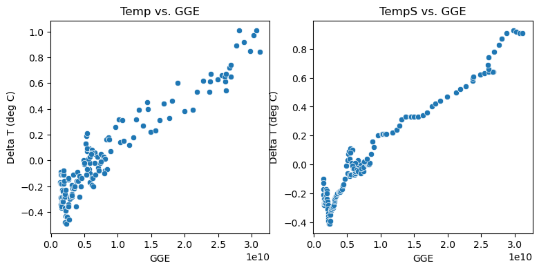

```python
# Plotting temperature versus greenhouse gas emissions
plot_y1_and_y2_versus_x1_and_x2(Combined_df2, 'GGE', 'GGE')
```

**Figure 3.2.2.1** Clearly, there is a positive correlation between greenhouse gas emissions and the temperature change, whether the raw temperature data Temp or the smoothed data TempS is used. There is some change in direction in the negative temperature range, which is probably in the period before 1950.

Next, we will examing the range from 1950 to 2021, for which we also have population data. To do so, the range of the greenhouse gas emissions will be adjusted and then added to the earlier Combined_df data frame. Finally, Temp and TempS will be plotted versus greenhouse gas emissions.

```python
# Select range from 1950 to 2021 of greenhouse gas emissions
World_GGE_1950_2021 = select_range(World_GGE, 1950, 2021)
```

```
First three lines:
  Country name      Code  Year           CO2       Methane           GGE
0        World  OWID_WRL  1950  5.929342e+09  3.665153e+09  9.594495e+09
1        World  OWID_WRL  1951  6.381406e+09  3.790647e+09  1.017205e+10
2        World  OWID_WRL  1952  6.467437e+09  3.878797e+09  1.034623e+10

Last three lines:
   Country name      Code  Year           CO2       Methane           GGE
69        World  OWID_WRL  2019  3.704010e+10  1.032124e+10  4.736135e+10
70        World  OWID_WRL  2020  3.500774e+10  1.037299e+10  4.538072e+10
71        World  OWID_WRL  2021  3.681654e+10  1.050691e+10  4.732346e+10
```

```python
# Adding greenhouse gas emissions data to Combined_df
Combined_df = combine_data(Combined_df, 'GGE', World_GGE_1950_2021, 'GGE')
Combined_df.head(3)
```

|  | Year | Temp | TempS | Pop | GGE |
| --- | --- | --- | --- | --- | --- |
| 0 | 1950 | -0.17 | -0.07 | 2499322000 | 9.594495e+09 |
| 1 | 1951 | -0.07 | -0.07 | 2543130400 | 1.017205e+10 |
| 2 | 1952 | 0.01 | -0.07 | 2590271000 | 1.034623e+10 |

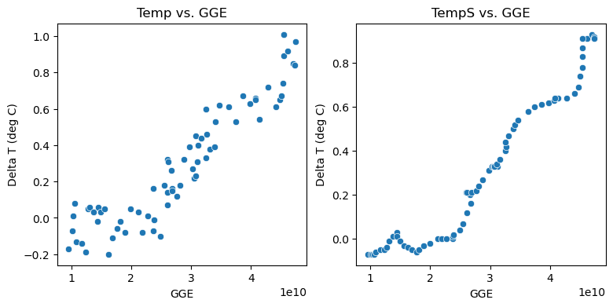

```python
# Plotting temperature versus greenhouse gas emissions
plot_y1_and_y2_versus_x1_and_x2(Combined_df, 'GGE', 'GGE')
```

**Figure 3.2.2.2** The correlation between temperature and greenhouse gas emissions since 1950 seems to be exponential rather than linear.

### 3.2.3 Greenhouse Gas Emissions and Population

What we have learned so far is that

- More humans on our planet are associated with higher temperatures.
- Higher greenhouse gas emissions are associated with higher temperatures.

The next question is: is there also a positive correlation between greenhouse gas emissions and population? While the answer seems obvious, there is quite some debate around this question. Initially, some people denied that there is global warming. Nowadays, that global warming is just too evident to be denied, it is more common for people to acknowledge that there is global warming, but to deny that it is caused by humans.

The following code will create a plot with greenhouse gas emissions versus population.

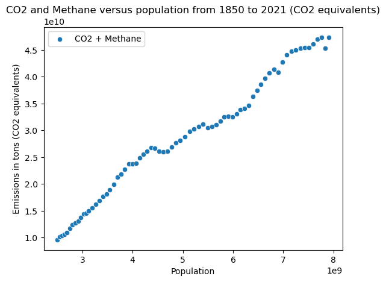

```python
# Plot GGE versus population
sns.scatterplot(data=Combined_df, x='Pop', y='GGE', label='CO2 + Methane')
plt.xlabel('Population')
plt.ylabel('Emissions in tons (CO2 equivalents)')
plt.title('CO2 and Methane versus population from 1850 to 2021 (CO2 equivalents)')
plt.show()
```

**Figure 3.2.3** This looks like a very strong linear correlation between greenhouse gas emissions and human population.

### 3.2.4 GDP and Population

In Figure 3.1.4, it appears that GDP has increased exponentially and at a more exponential rate than world population (Figure 3.1.2).  
To study this relationship, a data frame with GDP and Population is created. The Combined_df cannot be used, because it starts in 1950 rather than 1960. Greenhouse gas emissions (GGE) is included as well, because it is expected that GDP determines GGE.

Creating data frames of Population, GDP, and GGE from 1960 to 2021.

```python
# Creating a World_Pop data frame from 1960 to 2021
World_Pop_1960_2021 = select_range(World_Pop, 1960, 2021)
```

```
First three lines:
  Country name  Year         Pop
0        World  1960  3019233500
1        World  1961  3068370700
2        World  1962  3126686700

Last three lines:
   Country name  Year         Pop
59        World  2019  7764951000
60        World  2020  7840953000
61        World  2021  7909295000
```

```python
# Creating a World_GDP data frame from 1960 to 2021
World_GDP_1960_2021 = select_range(World_GDP, 1960, 2021)
```

```
First three lines:
   Year           GDP
0  1960  1.384860e+12
1  1961  1.449220e+12
2  1962  1.550820e+12

Last three lines:
    Year           GDP
59  2019  8.772810e+13
60  2020  8.521520e+13
61  2021  9.688240e+13
```

```python
# Creating a World_GGE data frame from 1960 to 2021
World_GGE_1960_2021 = select_range(World_GGE, 1960, 2021)
```

```
First three lines:
  Country name      Code  Year           CO2       Methane           GGE
0        World  OWID_WRL  1960  9.386421e+09  5.043982e+09  1.443040e+10
1        World  OWID_WRL  1961  9.414383e+09  5.101735e+09  1.451612e+10
2        World  OWID_WRL  1962  9.746556e+09  5.190937e+09  1.493749e+10

Last three lines:
   Country name      Code  Year           CO2       Methane           GGE
59        World  OWID_WRL  2019  3.704010e+10  1.032124e+10  4.736135e+10
60        World  OWID_WRL  2020  3.500774e+10  1.037299e+10  4.538072e+10
61        World  OWID_WRL  2021  3.681654e+10  1.050691e+10  4.732346e+10
```

```python
# Combining the data frames into a new data frame called Combined_df3
Combined_df3 = combine_data(World_Pop_1960_2021, 'GDP', World_GDP_1960_2021, 'GDP')
Combined_df3 = combine_data(Combined_df3, 'GGE', World_GGE_1960_2021, 'GGE')
Combined_df3.head(3)
```

|  | Country name | Year | Pop | GDP | GGE |
| --- | --- | --- | --- | --- | --- |
| 0 | World | 1960 | 3019233500 | 1.384860e+12 | 1.443040e+10 |
| 1 | World | 1961 | 3068370700 | 1.449220e+12 | 1.451612e+10 |
| 2 | World | 1962 | 3126686700 | 1.550820e+12 | 1.493749e+10 |

The following code will plot GDP versus population.

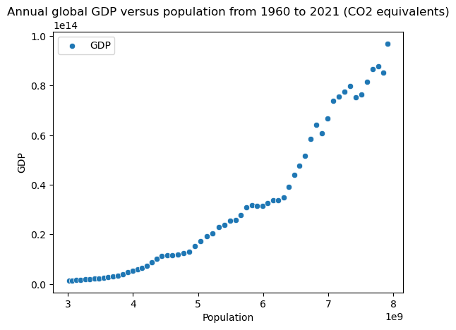

```python
# Plot GDP versus population
sns.scatterplot(data=Combined_df3, x='Pop', y='GDP', label='GDP')
plt.xlabel('Population')
plt.ylabel('GDP')
plt.title('Annual global GDP versus population from 1960 to 2021 (CO2 equivalents)')
plt.show()
```

**Figure 3.2.4** This figure indicates that the global GDP has been growing faster than the world population. This basically means that the per capita GDP has increased over time.

### 3.2.5 GGE and GDP

Next, it will be interesting to see how GDP affects greenhouse gas emissions.

The following code will plot GGE versus GDP.

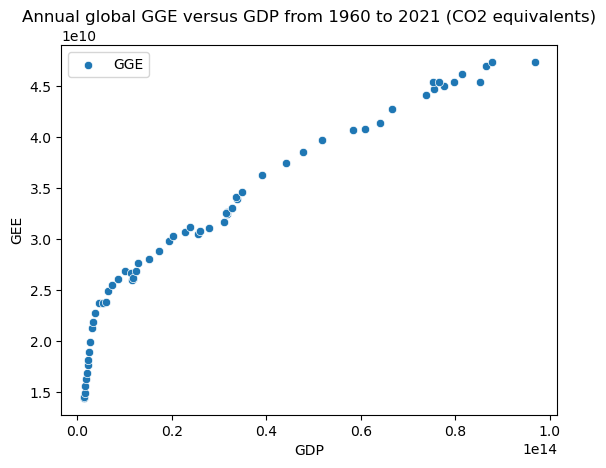

```python
# Plot GGE versus GDP
sns.scatterplot(data=Combined_df3, x='GDP', y='GGE', label='GGE')
plt.xlabel('GDP')
plt.ylabel('GEE')
plt.title('Annual global GGE versus GDP from 1960 to 2021 (CO2 equivalents)')
plt.show()
```

**Figure 3.2.5** This figure indicates that when the global GDP started increasing initially, greenhouse gas emissions increases drastically, but as the GDP reached more than ~0.1 x 10^14, GGE still increased but at a slower rate. The relationship seems to be biphasic. This observation gives some hope, because it indicates that a higher standard of living (GDP) for the entire world population could be achieved without dramatically increasing GGE.

The GDP is a construct calculated from various economic activities and does not seem to be a very good indicator for greenhouse gas emissions and global warming. It can be used, though, to stratify countries into different categories.

### 3.2.6 Temperature and GDP

Next, it will be interesting to see how GDP affects global temperature.

The following code will first prepare and add the relevant time frame of Temp and TempS to the data frame and then plot temperature versus GDP.

```python
# Select the relevant years of temperatures
World_Temp_1960_2021 = select_range(World_Temp, 1960, 2021)
# Add temperatures to Combined_df3
Combined_df3 = combine_data(Combined_df3, 'Temp', World_Temp_1960_2021, 'Temp')
Combined_df3 = combine_data(Combined_df3, 'TempS', World_Temp_1960_2021, 'TempS')
Combined_df3.head(3)
```

```
First three lines:
   Year  Temp  TempS
0  1960 -0.02   0.03
1  1961  0.06   0.01
2  1962  0.03  -0.01

Last three lines:
    Year  Temp  TempS
59  2019  0.97   0.92
60  2020  1.01   0.91
61  2021  0.84   0.91
```

|  | Country name | Year | Pop | GDP | GGE | Temp | TempS |
| --- | --- | --- | --- | --- | --- | --- | --- |
| 0 | World | 1960 | 3019233500 | 1.384860e+12 | 1.443040e+10 | -0.02 | 0.03 |
| 1 | World | 1961 | 3068370700 | 1.449220e+12 | 1.451612e+10 | 0.06 | 0.01 |
| 2 | World | 1962 | 3126686700 | 1.550820e+12 | 1.493749e+10 | 0.03 | -0.01 |

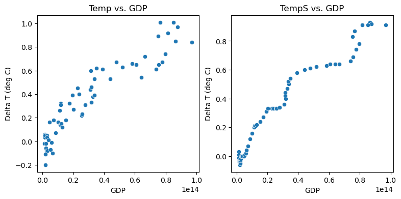

```python
# Plot Temp and TempS versus GDP
plot_y1_and_y2_versus_x1_and_x2(Combined_df3, 'GDP', 'GDP')
```

**Figure 3.2.6** Similar to the graph with GGE versus GDP, these plots are hyperbolic, indicating that GDP might not be a very good precidtor for global temperatures. Qualitatively, though, there is a clear relationship between GDP and temperature.

## 3.3 Stratifying data by Country Type

So far, we only looked at population, greenhouse gas emissions, and GDP for all countries (the World). Now, we will investigate if we can see any different trends in different types of countries.

### 3.3.1 By Income

Analysis of the population data frame pop_complete shows that we have four income categories. These are extracted and added to one data frame.

```python
# Printing out country names
# print(pop_complete['Country name'].unique())
```

```python
High_income_pop = select_country_range(pop_total, 'High-income countries', 1950, 2021)
```

```
First three lines:
            Country name  Year        Pop
0  High-income countries  1950  687356540
1  High-income countries  1951  694993200
2  High-income countries  1952  702997900

Last three lines:
             Country name  Year         Pop
69  High-income countries  2019  1240855700
70  High-income countries  2020  1244106800
71  High-income countries  2021  1245565600
```

```python
Upper_middle_income_pop = select_country_range(pop_total, 'Upper-middle-income countries', 1950, 2021)
```

```
First three lines:
                    Country name  Year        Pop
0  Upper-middle-income countries  1950  900338500
1  Upper-middle-income countries  1951  917683000
2  Upper-middle-income countries  1952  937054340

Last three lines:
                     Country name  Year         Pop
69  Upper-middle-income countries  2019  2501414100
70  Upper-middle-income countries  2020  2512477200
71  Upper-middle-income countries  2021  2519863600
```

```python
Lower_middle_income_pop = select_country_range(pop_total, 'Lower-middle-income countries', 1950, 2021)
```

```
First three lines:
                    Country name  Year        Pop
0  Lower-middle-income countries  1950  788620700
1  Lower-middle-income countries  1951  805591040
2  Lower-middle-income countries  1952  823223500

Last three lines:
                     Country name  Year         Pop
69  Lower-middle-income countries  2019  3313063400
70  Lower-middle-income countries  2020  3356047600
71  Lower-middle-income countries  2021  3396756500
```

```python
Low_income_pop = select_country_range(pop_total, 'Low-income countries', 1950, 2021)
```

```
First three lines:
           Country name  Year        Pop
0  Low-income countries  1950  117442280
1  Low-income countries  1951  119053230
2  Low-income countries  1952  120934696

Last three lines:
            Country name  Year        Pop
69  Low-income countries  2019  680013440
70  Low-income countries  2020  699186560
71  Low-income countries  2021  718255100
```

```python
Country_categories = High_income_pop
Country_categories.rename(columns = {'Pop': 'HiIncPop'}, inplace=True)
Country_categories = combine_data(Country_categories, 'UpMidIncPop', Upper_middle_income_pop, 'Pop')
Country_categories = combine_data(Country_categories, 'LoMidIncPop', Lower_middle_income_pop, 'Pop')
Country_categories = combine_data(Country_categories, 'LoIncPop', Low_income_pop, 'Pop')
Country_categories = Country_categories.drop(columns=('Country name'))
Country_categories.head(3)
```

|  | Year | HiIncPop | UpMidIncPop | LoMidIncPop | LoIncPop |
| --- | --- | --- | --- | --- | --- |
| 0 | 1950 | 687356540 | 900338500 | 788620700 | 117442280 |
| 1 | 1951 | 694993200 | 917683000 | 805591040 | 119053230 |
| 2 | 1952 | 702997900 | 937054340 | 823223500 | 120934696 |

The following plot will visualize population growth for the four different categories of countries.

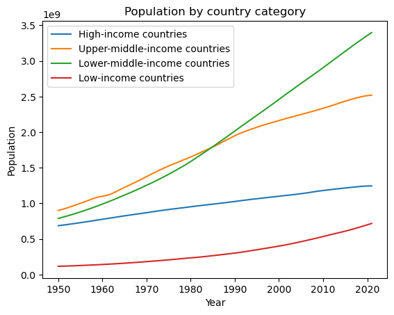

```python
# Plot different income countries' population versus year
sns.lineplot(data=Country_categories, x='Year', y='HiIncPop', label='High-income countries')
sns.lineplot(data=Country_categories, x='Year', y='UpMidIncPop', label='Upper-middle-income countries')
sns.lineplot(data=Country_categories, x='Year', y='LoMidIncPop', label='Lower-middle-income countries')
sns.lineplot(data=Country_categories, x='Year', y='LoIncPop', label='Low-income countries')
plt.xlabel('Year')
plt.ylabel('Population')
plt.title('Population by country category')
plt.show()
```

**Figure 3.3.1** This figure shows that different categories of countries experience different population growth. High-income and upper-middle-income countries have slowing growth, while Low-income and lower-middle-income countries have accelerated growth.

### 3.3.2 By Greenhouse Gas Emissions

The CO2_complete and Methane_complete data frames were analyzed. Again, we have the four same income categories and these were extracted and added to the Country_categories data frame.

```python
# print(CO2_complete['Country name'].unique())
```

```python
High_income_CO2 = select_country_range(CO2_complete, 'High-income countries', 1950, 2021)
```

```
First three lines:
            Country name Code  Year           CO2
0  High-income countries  NaN  1950  4.692989e+09
1  High-income countries  NaN  1951  5.008244e+09
2  High-income countries  NaN  1952  4.985601e+09

Last three lines:
             Country name Code  Year           CO2
69  High-income countries  NaN  2019  1.317918e+10
70  High-income countries  NaN  2020  1.201187e+10
71  High-income countries  NaN  2021  1.265564e+10
```

```python
Upper_middle_income_CO2 = select_country_range(CO2_complete, 'Upper-middle-income countries', 1950, 2021)
```

```
First three lines:
                    Country name Code  Year           CO2
0  Upper-middle-income countries  NaN  1950  8.201401e+08
1  Upper-middle-income countries  NaN  1951  9.156668e+08
2  Upper-middle-income countries  NaN  1952  1.000080e+09

Last three lines:
                     Country name Code  Year           CO2
69  Upper-middle-income countries  NaN  2019  1.625390e+10
70  Upper-middle-income countries  NaN  2020  1.613378e+10
71  Upper-middle-income countries  NaN  2021  1.685028e+10
```

```python
Lower_middle_income_CO2 = select_country_range(CO2_complete, 'Lower-middle-income countries', 1950, 2021)
```

```
First three lines:
                    Country name Code  Year          CO2
0  Lower-middle-income countries  NaN  1950  279561020.0
1  Lower-middle-income countries  NaN  1951  295216860.0
2  Lower-middle-income countries  NaN  1952  315366820.0

Last three lines:
                     Country name Code  Year           CO2
69  Lower-middle-income countries  NaN  2019  6.138582e+09
70  Lower-middle-income countries  NaN  2020  5.804352e+09
71  Lower-middle-income countries  NaN  2021  6.191859e+09
```

```python
Low_income_CO2 = select_country_range(CO2_complete, 'Low-income countries', 1950, 2021)
```

```
First three lines:
           Country name Code  Year        CO2
0  Low-income countries  NaN  1950  7947890.0
1  Low-income countries  NaN  1951  8720991.0
2  Low-income countries  NaN  1952  9891094.0

Last three lines:
            Country name Code  Year          CO2
69  Low-income countries  NaN  2019  203780930.0
70  Low-income countries  NaN  2020  198497810.0
71  Low-income countries  NaN  2021  210307470.0
```

```python
Country_categories = combine_data(Country_categories, 'HiIncCO2', High_income_CO2, 'CO2')
Country_categories = combine_data(Country_categories, 'UpMidIncCO2', Upper_middle_income_CO2, 'CO2')
Country_categories = combine_data(Country_categories, 'LoMidIncCO2', Lower_middle_income_CO2, 'CO2')
Country_categories = combine_data(Country_categories, 'LoIncCO2', Low_income_CO2, 'CO2')
Country_categories.head(3)
```

|  | Year | HiIncPop | UpMidIncPop | LoMidIncPop | LoIncPop | HiIncCO2 | UpMidIncCO2 | LoMidIncCO2 | LoIncCO2 |
| --- | --- | --- | --- | --- | --- | --- | --- | --- | --- |
| 0 | 1950 | 687356540 | 900338500 | 788620700 | 117442280 | 4.692989e+09 | 8.201401e+08 | 279561020.0 | 7947890.0 |
| 1 | 1951 | 694993200 | 917683000 | 805591040 | 119053230 | 5.008244e+09 | 9.156668e+08 | 295216860.0 | 8720991.0 |
| 2 | 1952 | 702997900 | 937054340 | 823223500 | 120934696 | 4.985601e+09 | 1.000080e+09 | 315366820.0 | 9891094.0 |

```python
# print(Methane_complete['Country name'].unique())
```

```python
High_income_methane = select_country_range(Methane_complete, 'High-income countries', 1950, 2021)
```

```
First three lines:
            Country name Code  Year       Methane
0  High-income countries  NaN  1950  1.420023e+09
1  High-income countries  NaN  1951  1.476386e+09
2  High-income countries  NaN  1952  1.496516e+09

Last three lines:
             Country name Code  Year       Methane
69  High-income countries  NaN  2019  2.177839e+09
70  High-income countries  NaN  2020  2.131159e+09
71  High-income countries  NaN  2021  2.151531e+09
```

```python
Upper_middle_income_methane = select_country_range(Methane_complete, 'Upper-middle-income countries', 1950, 2021)
```

```
First three lines:
                    Country name Code  Year       Methane
0  Upper-middle-income countries  NaN  1950  1.134521e+09
1  Upper-middle-income countries  NaN  1951  1.174314e+09
2  Upper-middle-income countries  NaN  1952  1.213150e+09

Last three lines:
                     Country name Code  Year       Methane
69  Upper-middle-income countries  NaN  2019  4.149197e+09
70  Upper-middle-income countries  NaN  2020  4.188202e+09
71  Upper-middle-income countries  NaN  2021  4.253935e+09
```

```python
Lower_middle_income_methane = select_country_range(Methane_complete, 'Lower-middle-income countries', 1950, 2021)
```

```
First three lines:
                    Country name Code  Year      Methane
0  Lower-middle-income countries  NaN  1950  859744700.0
1  Lower-middle-income countries  NaN  1951  882865500.0
2  Lower-middle-income countries  NaN  1952  906519500.0

Last three lines:
                     Country name Code  Year       Methane
69  Lower-middle-income countries  NaN  2019  3.254766e+09
70  Lower-middle-income countries  NaN  2020  3.296429e+09
71  Lower-middle-income countries  NaN  2021  3.331956e+09
```

```python
Low_income_methane = select_country_range(Methane_complete, 'Low-income countries', 1950, 2021)
```

```
First three lines:
           Country name Code  Year      Methane
0  Low-income countries  NaN  1950  140533650.0
1  Low-income countries  NaN  1951  143941090.0
2  Low-income countries  NaN  1952  147580770.0

Last three lines:
            Country name Code  Year      Methane
69  Low-income countries  NaN  2019  666996200.0
70  Low-income countries  NaN  2020  684816700.0
71  Low-income countries  NaN  2021  697219500.0
```

```python
Country_categories = combine_data(Country_categories, 'HiIncMet', High_income_methane, 'Methane')
Country_categories = combine_data(Country_categories, 'UpMidIncMet', Upper_middle_income_methane, 'Methane')
Country_categories = combine_data(Country_categories, 'LoMidIncMet', Lower_middle_income_methane, 'Methane')
Country_categories = combine_data(Country_categories, 'LoIncMet', Low_income_methane, 'Methane')
Country_categories.head(3)
```

|  | Year | HiIncPop | UpMidIncPop | LoMidIncPop | LoIncPop | HiIncCO2 | UpMidIncCO2 | LoMidIncCO2 | LoIncCO2 | HiIncMet | UpMidIncMet | LoMidIncMet | LoIncMet |
| --- | --- | --- | --- | --- | --- | --- | --- | --- | --- | --- | --- | --- | --- |
| 0 | 1950 | 687356540 | 900338500 | 788620700 | 117442280 | 4.692989e+09 | 8.201401e+08 | 279561020.0 | 7947890.0 | 1.420023e+09 | 1.134521e+09 | 859744700.0 | 140533650.0 |
| 1 | 1951 | 694993200 | 917683000 | 805591040 | 119053230 | 5.008244e+09 | 9.156668e+08 | 295216860.0 | 8720991.0 | 1.476386e+09 | 1.174314e+09 | 882865500.0 | 143941090.0 |
| 2 | 1952 | 702997900 | 937054340 | 823223500 | 120934696 | 4.985601e+09 | 1.000080e+09 | 315366820.0 | 9891094.0 | 1.496516e+09 | 1.213150e+09 | 906519500.0 | 147580770.0 |

Finally, columns for total greenhouse gas emissions (GEE) were added to the data frame.

```python
Country_categories['HiIncGGE'] = Country_categories.HiIncCO2 + Country_categories.HiIncMet
Country_categories['UpMidIncGGE'] = Country_categories.UpMidIncCO2 + Country_categories.UpMidIncMet
Country_categories['LoMidIncGGE'] = Country_categories.LoMidIncCO2 + Country_categories.LoMidIncMet
Country_categories['LoIncGGE'] = Country_categories.LoIncCO2 + Country_categories.LoIncMet
Country_categories.head(3)
```

|  | Year | HiIncPop | UpMidIncPop | LoMidIncPop | LoIncPop | HiIncCO2 | UpMidIncCO2 | LoMidIncCO2 | LoIncCO2 | HiIncMet | UpMidIncMet | LoMidIncMet | LoIncMet | HiIncGGE | UpMidIncGGE | LoMidIncGGE | LoIncGGE |
| --- | --- | --- | --- | --- | --- | --- | --- | --- | --- | --- | --- | --- | --- | --- | --- | --- | --- |
| 0 | 1950 | 687356540 | 900338500 | 788620700 | 117442280 | 4.692989e+09 | 8.201401e+08 | 279561020.0 | 7947890.0 | 1.420023e+09 | 1.134521e+09 | 859744700.0 | 140533650.0 | 6.113012e+09 | 1.954661e+09 | 1.139306e+09 | 148481540.0 |
| 1 | 1951 | 694993200 | 917683000 | 805591040 | 119053230 | 5.008244e+09 | 9.156668e+08 | 295216860.0 | 8720991.0 | 1.476386e+09 | 1.174314e+09 | 882865500.0 | 143941090.0 | 6.484630e+09 | 2.089980e+09 | 1.178082e+09 | 152662081.0 |
| 2 | 1952 | 702997900 | 937054340 | 823223500 | 120934696 | 4.985601e+09 | 1.000080e+09 | 315366820.0 | 9891094.0 | 1.496516e+09 | 1.213150e+09 | 906519500.0 | 147580770.0 | 6.482117e+09 | 2.213230e+09 | 1.221886e+09 | 157471864.0 |

The following figure will show the evolution in greenhouse gas emissions by country category.

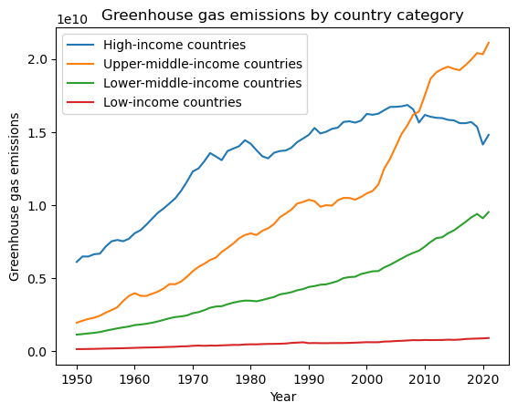

```python
# Plot different income countries' greenhouse gas emissions versus year
sns.lineplot(data=Country_categories, x='Year', y='HiIncGGE', label='High-income countries')
sns.lineplot(data=Country_categories, x='Year', y='UpMidIncGGE', label='Upper-middle-income countries')
sns.lineplot(data=Country_categories, x='Year', y='LoMidIncGGE', label='Lower-middle-income countries')
sns.lineplot(data=Country_categories, x='Year', y='LoIncGGE', label='Low-income countries')
plt.xlabel('Year')
plt.ylabel('Greenhouse gas emissions')
plt.title('Greenhouse gas emissions by country category')
plt.show()
```

### 3.3.3 By Greenhouse Gas Emissions per Capita

Since different countries have different population, it would be interesting to see which countries emit the most greenhouse gases per capita and what the trend is.

Therefore, GGE per capita (GGEpc) was calculated from the GGE and population data.

```python
Country_categories['HiIncGGEpc'] = Country_categories.HiIncGGE / Country_categories.HiIncPop
Country_categories['UpMidIncGGEpc'] = Country_categories.UpMidIncGGE / Country_categories.UpMidIncPop
Country_categories['LoMidIncGGEpc'] = Country_categories.LoMidIncGGE / Country_categories.LoMidIncPop
Country_categories['LoIncGGEpc'] = Country_categories.LoIncGGE / Country_categories.LoIncPop
Country_categories.head(3)
```

|  | Year | HiIncPop | UpMidIncPop | LoMidIncPop | LoIncPop | HiIncCO2 | UpMidIncCO2 | LoMidIncCO2 | LoIncCO2 | HiIncMet | ... | LoMidIncMet | LoIncMet | HiIncGGE | UpMidIncGGE | LoMidIncGGE | LoIncGGE | HiIncGGEpc | UpMidIncGGEpc | LoMidIncGGEpc | LoIncGGEpc |
| --- | --- | --- | --- | --- | --- | --- | --- | --- | --- | --- | --- | --- | --- | --- | --- | --- | --- | --- | --- | --- | --- |
| 0 | 1950 | 687356540 | 900338500 | 788620700 | 117442280 | 4.692989e+09 | 8.201401e+08 | 279561020.0 | 7947890.0 | 1.420023e+09 | ... | 859744700.0 | 140533650.0 | 6.113012e+09 | 1.954661e+09 | 1.139306e+09 | 148481540.0 | 8.893509 | 2.171029 | 1.444681 | 1.264294 |
| 1 | 1951 | 694993200 | 917683000 | 805591040 | 119053230 | 5.008244e+09 | 9.156668e+08 | 295216860.0 | 8720991.0 | 1.476386e+09 | ... | 882865500.0 | 143941090.0 | 6.484630e+09 | 2.089980e+09 | 1.178082e+09 | 152662081.0 | 9.330493 | 2.277454 | 1.462383 | 1.282301 |
| 2 | 1952 | 702997900 | 937054340 | 823223500 | 120934696 | 4.985601e+09 | 1.000080e+09 | 315366820.0 | 9891094.0 | 1.496516e+09 | ... | 906519500.0 | 147580770.0 | 6.482117e+09 | 2.213230e+09 | 1.221886e+09 | 157471864.0 | 9.220678 | 2.361902 | 1.484270 | 1.302123 |

3 rows × 21 columns

The following figure will show the development of greenhouse gas emissions per capita by country category.

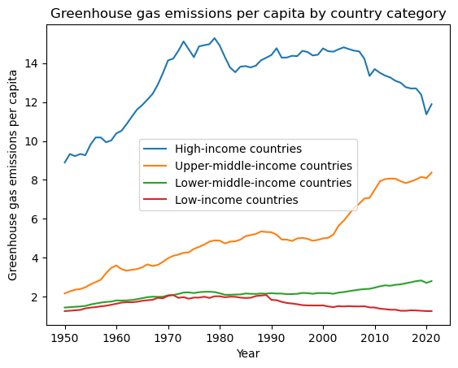

```python
# Plot different income countries' greenhouse gas emissions per capita versus year
sns.lineplot(data=Country_categories, x='Year', y='HiIncGGEpc', label='High-income countries')
sns.lineplot(data=Country_categories, x='Year', y='UpMidIncGGEpc', label='Upper-middle-income countries')
sns.lineplot(data=Country_categories, x='Year', y='LoMidIncGGEpc', label='Lower-middle-income countries')
sns.lineplot(data=Country_categories, x='Year', y='LoIncGGEpc', label='Low-income countries')
plt.xlabel('Year')
plt.ylabel('Greenhouse gas emissions per capita')
plt.title('Greenhouse gas emissions per capita by country category')
plt.show()
```

**Figure 3.3.3** This figure clearly shows that, while greenhouse gas emissions in high-income countries are decreasing, they are still the highest per capita. In upper-middle-income countries they are rapidly increasing. In low-middle-income countries they are also increasing, but they account for a small percentage. In low-income countries they are very low and decreasing even further.

So, in a nutshell, the richest are causing the most damage and the poorest cause the least damage. On the other hand, the poorest are probably most affected by climate change through, e.g., the lack of drinking water and food caused by droughts.

We can use this stratified data to refine our models below to find out which category of countries' population and greenhouse gas emissions are most closely correlated with the global population and greenhouse gas emissions as well as global warming. Therefore, global population, global GGE, and Temp and TempS will be added to the Country_categories data frame.

```python
# Adding total population
Country_categories = combine_data(Country_categories, 'Pop', World_Pop, 'Pop')
Country_categories = combine_data(Country_categories, 'GGE', World_GGE, 'GGE')
Country_categories = combine_data(Country_categories, 'Temp', World_Temp, 'Temp')
Country_categories = combine_data(Country_categories, 'TempS', World_Temp, 'TempS')
Country_categories.head(3)
```

[output not shown]

3 rows × 25 columns

# 4 Model Choice and Model Results

## 4.1 Temperature versus Population

### 4.1.1 Linear Model

#### 4.1.1.1 Rationale for Linear Model Choice

Figure 3.2.1 shows an apparent linear or perhaps exponential correlation between world population and Temperature. While time series data are not ideal for linear models because the data are not identically independently distributed (iid), a linear model can be a good tool to describe relationships.

#### 4.1.1.2 Linear Model Building

The code below builds linear models with temperature change (actual data or smoothed) as dependent variable and population as independent variable.

```python
# Build a linear model with the raw temperature data
pop_temp_lm = smf.ols(formula = 'Temp ~ Pop', data=Combined_df).fit()
pop_temp_lm.summary()
```

OLS Regression Results

| Dep. Variable: | Temp | R-squared: | 0.898 |
| --- | --- | --- | --- |
| Model: | OLS | Adj. R-squared: | 0.897 |
| Method: | Least Squares | F-statistic: | 619.6 |
| Date: | Thu, 21 Dec 2023 | Prob (F-statistic): | 1.69e-36 |
| Time: | 16:19:42 | Log-Likelihood: | 59.627 |
| No. Observations: | 72 | AIC: | -115.3 |
| Df Residuals: | 70 | BIC: | -110.7 |
| Df Model: | 1 |  |  |
| Covariance Type: | nonrobust |  |  |

|  | coef | std err | t | P>\|t\| | [0.025 | 0.975] |
| --- | --- | --- | --- | --- | --- | --- |
| Intercept | -0.6582 | 0.041 | -16.252 | 0.000 | -0.739 | -0.577 |
| Pop | 1.912e-10 | 7.68e-12 | 24.891 | 0.000 | 1.76e-10 | 2.07e-10 |

| Omnibus: | 2.294 | Durbin-Watson: | 1.189 |
| --- | --- | --- | --- |
| Prob(Omnibus): | 0.318 | Jarque-Bera (JB): | 1.485 |
| Skew: | 0.057 | Prob(JB): | 0.476 |
| Kurtosis: | 2.306 | Cond. No. | 1.69e+10 |

Notes:  
[1] Standard Errors assume that the covariance matrix of the errors is correctly specified.  
[2] The condition number is large, 1.69e+10. This might indicate that there are  
strong multicollinearity or other numerical problems.

```python
# Build a linear model with the smoothed temperature data
pop_temp_smooth_lm = smf.ols(formula = 'TempS ~ Pop', data=Combined_df).fit()
pop_temp_smooth_lm.summary()
```

OLS Regression Results

| Dep. Variable: | TempS | R-squared: | 0.962 |
| --- | --- | --- | --- |
| Model: | OLS | Adj. R-squared: | 0.961 |
| Method: | Least Squares | F-statistic: | 1757. |
| Date: | Thu, 21 Dec 2023 | Prob (F-statistic): | 2.51e-51 |
| Time: | 16:19:42 | Log-Likelihood: | 97.720 |
| No. Observations: | 72 | AIC: | -191.4 |
| Df Residuals: | 70 | BIC: | -186.9 |
| Df Model: | 1 |  |  |
| Covariance Type: | nonrobust |  |  |

|  | coef | std err | t | P>\|t\| | [0.025 | 0.975] |
| --- | --- | --- | --- | --- | --- | --- |
| Intercept | -0.6515 | 0.024 | -27.304 | 0.000 | -0.699 | -0.604 |
| Pop | 1.898e-10 | 4.53e-12 | 41.922 | 0.000 | 1.81e-10 | 1.99e-10 |

| Omnibus: | 11.622 | Durbin-Watson: | 0.070 |
| --- | --- | --- | --- |
| Prob(Omnibus): | 0.003 | Jarque-Bera (JB): | 4.934 |
| Skew: | 0.390 | Prob(JB): | 0.0849 |
| Kurtosis: | 1.982 | Cond. No. | 1.69e+10 |

Notes:  
[1] Standard Errors assume that the covariance matrix of the errors is correctly specified.  
[2] The condition number is large, 1.69e+10. This might indicate that there are  
strong multicollinearity or other numerical problems.

#### 4.1.1.3 Linear Model Results

Both models have a high R squared and adjusted R squared, the one for Temp of about 0.90 and the one for TempS of about 0.96. However, in both models the condition number is very large, indicating there might be some multicollinearity or other problems with the models. This is most likely because they are both time series data.

To further analyze the residuals, the predicted values and residuals are calculated and added to the data frame.

```python
# Add predicted values of linear models to dataframe
Combined_df['Temp_LM_pred'] = pop_temp_lm.predict(Combined_df.Pop)
Combined_df['TempS_LM_pred'] = pop_temp_smooth_lm.predict(Combined_df.Pop)
```

```python
# Add residuals of linear models to dataframe
Combined_df['Temp_LM_resids'] = np.subtract(Combined_df.Temp_LM_pred, Combined_df.Temp)
Combined_df['TempS_LM_resids'] = np.subtract(Combined_df.TempS_LM_pred, Combined_df.TempS)
Combined_df.head(3)
```

|  | Year | Temp | TempS | Pop | GGE | Temp_LM_pred | TempS_LM_pred | Temp_LM_resids | TempS_LM_resids |
| --- | --- | --- | --- | --- | --- | --- | --- | --- | --- |
| 0 | 1950 | -0.17 | -0.07 | 2499322000 | 9.594495e+09 | -0.180266 | -0.177250 | -0.010266 | -0.107250 |
| 1 | 1951 | -0.07 | -0.07 | 2543130400 | 1.017205e+10 | -0.171889 | -0.168937 | -0.101889 | -0.098937 |
| 2 | 1952 | 0.01 | -0.07 | 2590271000 | 1.034623e+10 | -0.162874 | -0.159992 | -0.172874 | -0.089992 |

The following code defines a function to plot actual and predicted values versus the predictor variable(s).

```python
def plot_y1_and_y2_and_yhat1_and_yhat2_versus_x1_and_x2(df, x1, x2, y1='Temp',\
                                       y2='TempS', yhat1='Temp_LM_pred', \
                                       yhat2='TempS_LM_pred', ylabel='Delta T (deg C)'):
    fig,ax = plt.subplots(1, 2, figsize=(9,4))
    ax[0] = sns.lineplot(x=x1, y=yhat1, data=df, color='red', ax=ax[0])
    ax[0] = sns.scatterplot(x=x1, y=y1, data=df, ax=ax[0])
    ax[0].set_title('Observed and predicted ' + y1 + '\n vs. ' +  x1)
    ax[1] = sns.lineplot(x=x2, y=yhat2, data=df, color='red', ax=ax[1])
    ax[1] = sns.scatterplot(x=x2, y=y2, data=df, ax=ax[1])
    ax[1].set_title('Observed and predicted ' + y2 + '\n vs. ' +  x1)
    plt.show()
```

The code below plots the actual temperature values (blue points) together with the predicted ones (red lines) versus population.

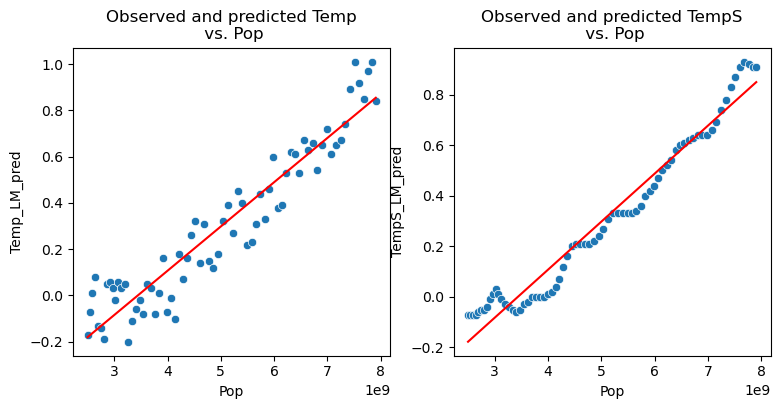

```python
plot_y1_and_y2_and_yhat1_and_yhat2_versus_x1_and_x2(Combined_df, 'Pop', 'Pop')
```

```python
print('Temp: The mean of the residuals = {0:4.3f}  RMSE = {1:4.3f}'.format(np.mean(Combined_df.Temp_LM_resids), np.std(Combined_df.Temp_LM_resids)))
print('TempS: The mean of the residuals = {0:4.3f}  RMSE = {1:4.3f}'.format(np.mean(Combined_df.TempS_LM_resids), np.std(Combined_df.TempS_LM_resids)))
```

```
Temp: The mean of the residuals = 0.000  RMSE = 0.106
TempS: The mean of the residuals = 0.000  RMSE = 0.062
```

**Figure 4.1.1.3.1** The fits look generally good. The RMSE with the smoothed temperatures has a lower RMSE, but the plot indicates that the model might not be ideal.

Next, the distributions of the residuals are analyzed.

```python
# Analysis of residuals of temp
# Borrowing code from Notebook 19
def plot_resid_dist(resids):
    fig, ax = plt.subplots(nrows=1, ncols=2, figsize=(12, 5))
    ## Plot a histogram
    sns.histplot(resids, bins=20, kde=True, ax=ax[0])
    ax[0].set_title('Histogram of residuals')
    ax[0].set_xlabel('Residual values')
    ## Plot the Q-Q Normal plot
    ss.probplot(resids, plot = ax[1])
    ax[1].set_title('Q-Q Normal plot of residuals')
    plt.show()
```

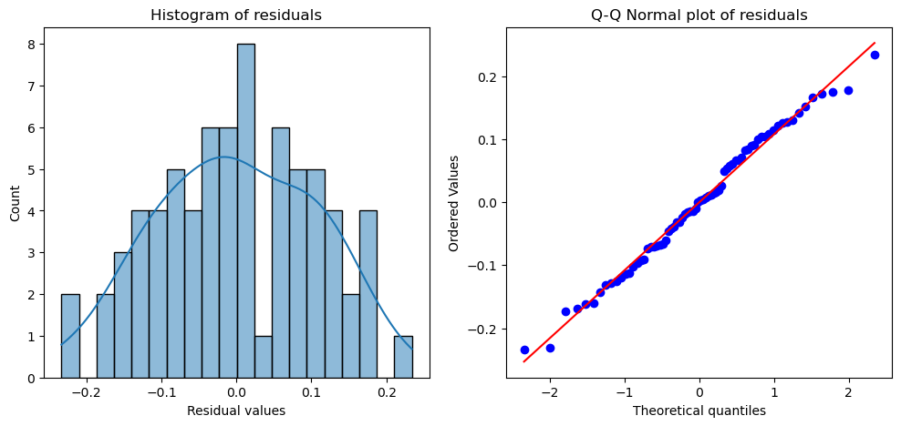

```python
plot_resid_dist(Combined_df.Temp_LM_resids)
```

**Figure 4.1.1.3.2** The residuals of the linear model with the raw temperature data Temp look approximately normally distributed.

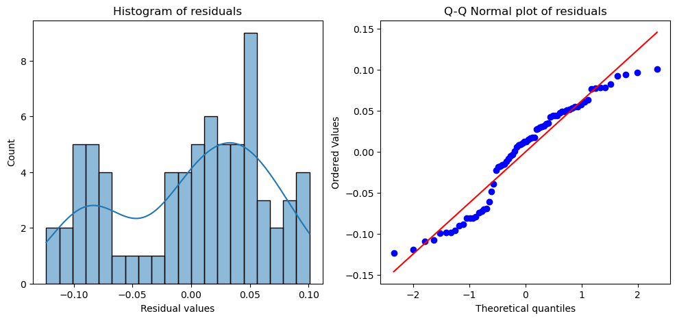

```python
plot_resid_dist(Combined_df.TempS_LM_resids)
```

**Figure 4.1.1.3.3** The residuals of the linear model with the smoothed temperature data TempS have a bimodal distribution.

Next, the residuals versus predicted values are plotted to find out if the residuals are homoskedastic.

```python
# Analysis of residuals of temp
# Borrowing code from Notebook 19
def residual_plot(df, predicted='predicted', resids='resids'):
    fig,ax = plt.subplots(figsize=(12,5))
    RMSE = np.std(df.loc[:,resids])
    sns.scatterplot(x=predicted, y=resids, data=df, ax=ax)
    ax.axhline(0.0, color='red', linewidth=1.0)
    ax.axhline(2.0*RMSE, color='red', linestyle='dashed', linewidth=1.0)
    ax.axhline(-2.0*RMSE, color='red', linestyle='dashed', linewidth=1.0)
    ax.set_title('PLot of residuals vs. predicted')
    ax.set_xlabel('Predicted values')
    ax.set_ylabel('Residuals')
    plt.show()
```

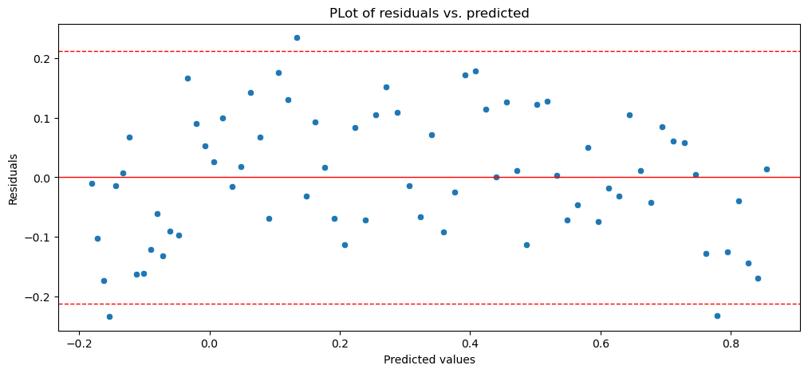

```python
residual_plot(Combined_df, 'Temp_LM_pred', 'Temp_LM_resids')
```

**Figure 4.1.1.3.4** The residuals of the linear model with the raw temperature data are approximately homoskedastic.

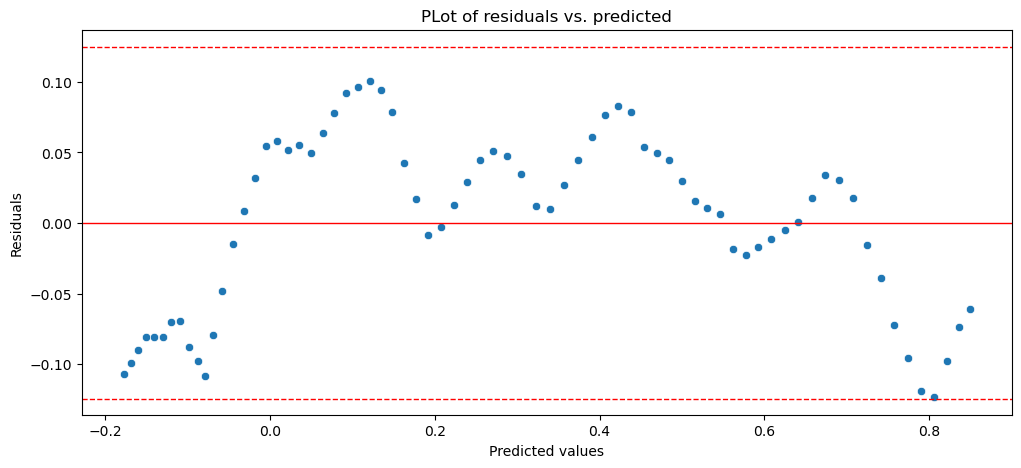

```python
residual_plot(Combined_df, 'TempS_LM_pred', 'TempS_LM_resids')
```

**Figure 4.1.1.3.5** The residuals of the linear model with the smoothed temperature data are heteroskedastic.

As outlined in the project proposal, including binomial terms and a logarithmic transformation were attempted but did not improve the model. So, the basic linear model will be accepted as the best linear model.

## 4.2 Temperature versus Greenhouse Gas Emissions

### 4.2.1 Linear Model

#### 4.2.1.1 Rationale for Linear Model Choice

Figure 3.2.2.2 shows an apparent linear or perhaps exponential correlation between temperature and greenhouse gas emissions. While time series data are not ideal for linear models because the data are not identically independently distributed (iid), a linear model can be a good tool to describe relationships.

#### 4.2.1.2 Linear Model Building

The code below builds linear models with temperature change (actual data or smoothed) as dependent variable and greenhouse gas emissions as independent variable. GGE stands for CO2 + Methane greenhouse gas emissions.

```python
# Build a linear model with the raw temperature data
GGE_temp_lm = smf.ols(formula = 'Temp ~ GGE', data=Combined_df).fit()
GGE_temp_lm.summary()
```

OLS Regression Results

| Dep. Variable: | Temp | R-squared: | 0.866 |
| --- | --- | --- | --- |
| Model: | OLS | Adj. R-squared: | 0.864 |
| Method: | Least Squares | F-statistic: | 454.0 |
| Date: | Thu, 21 Dec 2023 | Prob (F-statistic): | 2.58e-32 |
| Time: | 16:19:43 | Log-Likelihood: | 49.741 |
| No. Observations: | 72 | AIC: | -95.48 |
| Df Residuals: | 70 | BIC: | -90.93 |
| Df Model: | 1 |  |  |
| Covariance Type: | nonrobust |  |  |

|  | coef | std err | t | P>\|t\| | [0.025 | 0.975] |
| --- | --- | --- | --- | --- | --- | --- |
| Intercept | -0.4787 | 0.039 | -12.181 | 0.000 | -0.557 | -0.400 |
| GGE | 2.747e-11 | 1.29e-12 | 21.307 | 0.000 | 2.49e-11 | 3e-11 |

| Omnibus: | 0.496 | Durbin-Watson: | 0.954 |
| --- | --- | --- | --- |
| Prob(Omnibus): | 0.780 | Jarque-Bera (JB): | 0.624 |
| Skew: | 0.023 | Prob(JB): | 0.732 |
| Kurtosis: | 2.546 | Cond. No. | 8.26e+10 |

Notes:  
[1] Standard Errors assume that the covariance matrix of the errors is correctly specified.  
[2] The condition number is large, 8.26e+10. This might indicate that there are  
strong multicollinearity or other numerical problems.

```python
# Build a linear model with the smoothed temperature data
GGE_tempS_lm = smf.ols(formula = 'TempS ~ GGE', data=Combined_df).fit()
GGE_tempS_lm.summary()
```

OLS Regression Results

| Dep. Variable: | TempS | R-squared: | 0.929 |
| --- | --- | --- | --- |
| Model: | OLS | Adj. R-squared: | 0.928 |
| Method: | Least Squares | F-statistic: | 909.4 |
| Date: | Thu, 21 Dec 2023 | Prob (F-statistic): | 7.73e-42 |
| Time: | 16:19:43 | Log-Likelihood: | 75.266 |
| No. Observations: | 72 | AIC: | -146.5 |
| Df Residuals: | 70 | BIC: | -142.0 |
| Df Model: | 1 |  |  |
| Covariance Type: | nonrobust |  |  |

|  | coef | std err | t | P>\|t\| | [0.025 | 0.975] |
| --- | --- | --- | --- | --- | --- | --- |
| Intercept | -0.4738 | 0.028 | -17.188 | 0.000 | -0.529 | -0.419 |
| GGE | 2.727e-11 | 9.04e-13 | 30.156 | 0.000 | 2.55e-11 | 2.91e-11 |

| Omnibus: | 5.027 | Durbin-Watson: | 0.066 |
| --- | --- | --- | --- |
| Prob(Omnibus): | 0.081 | Jarque-Bera (JB): | 2.375 |
| Skew: | -0.122 | Prob(JB): | 0.305 |
| Kurtosis: | 2.144 | Cond. No. | 8.26e+10 |

Notes:  
[1] Standard Errors assume that the covariance matrix of the errors is correctly specified.  
[2] The condition number is large, 8.26e+10. This might indicate that there are  
strong multicollinearity or other numerical problems.